# Holtemme publication workflow - Site-associated co-expression modules, contrast robustness, and whole-module functional interpretation

Camilo Escobar

# 1 Purpose and analytical position

This report finalises a site-first interpretation of the Holtemme WGCNA network. It does not reconstruct the network and does not use chemistry to select modules. Instead, it follows five ordered questions:

1. Which module eigengenes differ among the six sampling sites or across the three predefined river transitions?
2. Which modules retain acceptable membership and eigengene-profile stability across a declared 14-network sensitivity scheme?
3. Which biological functions are enriched in the complete gene membership of those modules, using the selected WGCNA gene universe as the functional background?
4. Which differentially expressed genes and highly connected genes provide gene-level support for the module interpretation?
5. Do total predicted mixture pressure or selected mode-of-action (MoA) profiles provide compatible chemical context for the independently selected modules?

The network was constructed from 30 individual RNA-seq libraries. Site effects and planned module-eigengene contrasts are therefore evaluated from individual library values. Chemistry remains measured once per site; chemistry overlays use six site means and are treated as secondary, hypothesis-generating context.

Module eigengene signs are mathematically arbitrary. A positive site contrast means that the module eigengene had a higher value at the numerator site; it does not by itself mean that every gene in the module was upregulated. Gene-level expression direction is evaluated separately using the focal differential- expression contrasts.

The valid non-grey modules multiplied by the three predefined contrasts form the sole primary inferential family. Omnibus site tests are supplementary, and chemistry never selects modules.

# 2 0. Setup and configuration

# 3 1. Input manifest

Input manifest for the Step 08 site-first module analysis.

| input_id | path | required | role | present |
| --- | --- | --- | --- | --- |
| selected_network_manifest | ../Results_07_WGCNA_Network_Selection/tables/selected_wgcna_network_manifest.csv | TRUE | Step 07 evidence-based WGCNA network and settings handoff | TRUE |
| module_eigengenes_by_sample | ../Results_07_WGCNA_Network_Selection/tables/selected_wgcna_module_eigengenes_by_sample.csv | TRUE | individual-library module eigengenes for site tests | TRUE |
| module_eigengenes_by_site | ../Results_07_WGCNA_Network_Selection/tables/selected_wgcna_module_eigengenes_by_site.csv | TRUE | site-mean eigengenes for chemistry context | TRUE |
| module_summary | ../Results_07_WGCNA_Network_Selection/tables/selected_wgcna_module_summary.csv | TRUE | module sizes and identifiers | TRUE |
| gene_membership | ../Results_07_WGCNA_Network_Selection/tables/selected_wgcna_gene_module_membership.csv | TRUE | complete network membership and signed kME | TRUE |
| hub_candidates | ../Results_07_WGCNA_Network_Selection/tables/selected_wgcna_hub_gene_candidates_top25_by_module.csv | FALSE | precomputed top connected genes | FALSE |
| soft_threshold_diagnostics | ../Results_07_WGCNA_Network_Selection/tables/selected_wgcna_soft_threshold_diagnostics.csv | FALSE | soft-threshold fit and connectivity diagnostics | TRUE |
| soft_threshold_decision | ../Results_07_WGCNA_Network_Selection/tables/selected_wgcna_soft_threshold_decision.csv | FALSE | selected power and decision rule | TRUE |
| vst_matrix | ../Results_01_Global_Transcriptome_Structure/matrices/vst_matrix_germany.tsv | TRUE | individual-library expression matrix used to regenerate module stability | TRUE |
| metadata_matched | ../Results_01_Global_Transcriptome_Structure/tables/metadata_matched_germany.csv | TRUE | sample-to-site mapping used for site-stratified stability resampling | TRUE |
| gene_lengths | ../Results_04_EchoGO_Seed_Preparation/derived_inputs/gene_lengths_from_fasta_and_map.csv | TRUE | gene-level length proxy for module enrichment | TRUE |
| gene_to_go_primary | ../Results_04_EchoGO_Seed_Preparation/derived_inputs/gene_to_go_primary_eggnog_long.csv | TRUE | primary EggNOG gene-to-GO mapping | TRUE |
| gene_to_go_union | ../Results_04_EchoGO_Seed_Preparation/derived_inputs/gene_to_go_sensitivity_union_long.csv | TRUE | declared broader Trinotate GO-mapping sensitivity layer | TRUE |
| gene_to_kegg_pathway | ../Results_04_EchoGO_Seed_Preparation/derived_inputs/gene_to_kegg_pathway_primary_long.csv | TRUE | supportive EggNOG-derived KEGG pathway mapping | TRUE |
| trinotate_report | ../03_reference/Trinotate_report.tsv | TRUE | EggNOG and Swiss-Prot evidence used for provenance-aware gene labels | TRUE |
| step06_term_gene | ../Results_06_Functional_Synthesis/tables/master/supplementary_consensus_term_gene_transcript_long.csv | FALSE | existing paper-theme and functional traceback vocabulary | TRUE |
| total_pressure | ../02_inputs/STU_log10STU_per_site.tsv | FALSE | total predicted mixture pressure by site | TRUE |
| moa_pressure | ../02_inputs/TU_per_site-MoA.tsv | FALSE | direct MoA-specific summed TUs by site | TRUE |

# 4 2. Network-design transparency and input quality control

This section records what the existing network represents. It does not treat the scale-free-topology statistic as a measure of network accuracy. The site-first analysis below asks whether the recovered modules carry reproducible biological information across the 30 libraries; network construction remains an upstream unsupervised step.

Provenance of the reporting labels assigned to the 10,000 network genes; label choice does not alter GOseq statistics.

| label_source | n_network_genes | fraction_network_genes |
| --- | --- | --- |
| eggnog_description | 226 | 0.023 |
| eggnog_preferred_name | 829 | 0.083 |
| swissprot_blastx_description | 2 | 0.000 |
| trinity_gene_id | 8176 | 0.818 |
| unambiguous_swissprot_blastp_symbol | 276 | 0.028 |
| unambiguous_swissprot_blastx_symbol | 491 | 0.049 |

Individual RNA-seq libraries contributing to the module-eigengene site tests.

| site | n_libraries |
| --- | --- |
| H2 | 5 |
| H3 | 5 |
| H4 | 5 |
| H5 | 5 |
| H6 | 5 |
| H7 | 5 |

Network gene and module coverage.

| n_network_genes | n_assigned_genes | n_grey_genes | n_assigned_modules | n_individual_libraries |
| --- | --- | --- | --- | --- |
| 10000 | 6087 | 3913 | 18 | 30 |

Transparent interpretation of the upstream WGCNA design parameters.

| parameter | value | interpretation |
| --- | --- | --- |
| Network source | Step 07 selected G10000 network | the final network is consumed from the explicit Step 07 handoff |
| Input expression | VST values from 30 individual libraries | correlations are estimated across biological libraries, not site centroids |
| Gene universe | 10000 | network represents the selected variance-ranked expression space |
| Similarity | biweight midcorrelation; maxPOutliers = 0.10 | robust correlation reduces the influence of a limited number of extreme observations |
| Network type | signed | positive co-expression is retained; negative correlations approach weak adjacency |
| Soft-threshold power | 14 | correlations are continuously reweighted rather than hard-thresholded |
| Scale-free fit at selected power | 0.547 | diagnostic fit to a scale-free connectivity approximation; not network accuracy |
| Scale-free target reached | FALSE | the target is a diagnostic criterion and was not used alone to select the network |
| Mean connectivity at selected power | 102.51 | average weighted connectivity retained after soft thresholding |
| Topological overlap | signed TOM | genes are grouped using direct adjacency and shared network neighbours |
| Minimum module size | 50 genes | smaller branches are not retained as independent modules |
| Deep split | 2 | dynamic-tree-cut sensitivity retained from the selected network |
| Merge cut height | 0.25 | preliminary modules with eigengene correlation above approximately 0.75 are merged |
| Maximum block size | 6000 | the Step 08 robustness networks retain the Step 07 blockwise topology regime |
| Reference network blocks | 2 | block count is reported because larger gene universes require blockwise construction |
| Stability power variants | 12 and 16 | full-data sensitivity powers are centered plus/minus two around the selected power |
| Unassigned genes | grey module | genes without a sufficiently coherent module profile remain unassigned |

# 5 3. Module stability under resampling and parameter variation

Module membership stability is evaluated before modules are interpreted. The declared scheme contains 14 alternative networks: ten site-stratified subsamples retaining four of five libraries per site, two full-data soft-power variants at plus/minus two from the selected power, and two full-data merge-height variants (0.15 and 0.35). Each reference module is matched to the alternative module with the greatest gene-membership Jaccard index. Absolute eigengene-profile agreement is evaluated after projecting each alternative assignment onto all 30 libraries.

The diagnostic is descriptive rather than a preservation significance test. `high` and `moderate` modules pass the stability gate; `low` modules can be shown as exploratory patterns but cannot support a paper-facing module claim. Cached results are reused only when the source files, WGCNA version, random seed, and declared settings have an identical fingerprint.

Predeclared module-stability classification and evidence gate.

| stability_class | median_resampling_jaccard | median_parameter_jaccard | minimum_jaccard_all | median_eigengene_agreement | paper_facing_gate |
| --- | --- | --- | --- | --- | --- |
| high | >= 0.75 | >= 0.75 | >= 0.50 | >= 0.90 | pass |
| moderate | >= 0.50 | >= 0.50 | >= 0.25 | >= 0.80 | pass |
| low | below moderate rule | below moderate rule | below moderate rule | below moderate rule | fail |

Module preservation across the declared 14-network sensitivity scheme.

| module | module_label | n_variants | median_jaccard_all | minimum_jaccard_all | median_eigengene_abs_correlation_all | median_jaccard_resampling | minimum_jaccard_resampling | median_jaccard_parameter | minimum_jaccard_parameter | reciprocal_match_fraction | one_to_many_or_merged_variant_n | stability_class | stability_gate_pass | stability_source |
| --- | --- | --- | --- | --- | --- | --- | --- | --- | --- | --- | --- | --- | --- | --- |
| turquoise | MEturquoise | 14 | 0.822 | 0.676 | 1.000 | 0.810 | 0.676 | 0.997 | 0.993 | 1.000 | 2 | high | TRUE | regenerated_declared_14_network_scheme |
| brown | MEbrown | 14 | 0.707 | 0.651 | 0.999 | 0.693 | 0.651 | 0.995 | 0.989 | 1.000 | 1 | moderate | TRUE | regenerated_declared_14_network_scheme |
| green | MEgreen | 14 | 0.644 | 0.570 | 0.999 | 0.630 | 0.570 | 0.987 | 0.969 | 1.000 | 0 | moderate | TRUE | regenerated_declared_14_network_scheme |
| blue | MEblue | 14 | 0.599 | 0.339 | 0.995 | 0.579 | 0.339 | 0.966 | 0.879 | 1.000 | 8 | moderate | TRUE | regenerated_declared_14_network_scheme |
| magenta | MEmagenta | 14 | 0.539 | 0.296 | 0.995 | 0.509 | 0.296 | 0.959 | 0.908 | 1.000 | 1 | moderate | TRUE | regenerated_declared_14_network_scheme |
| grey60 | MEgrey60 | 14 | 0.504 | 0.016 | 0.991 | 0.472 | 0.016 | 0.995 | 0.928 | 0.857 | 2 | low | FALSE | regenerated_declared_14_network_scheme |
| pink | MEpink | 14 | 0.463 | 0.244 | 0.994 | 0.452 | 0.244 | 0.956 | 0.905 | 0.929 | 3 | low | FALSE | regenerated_declared_14_network_scheme |
| purple | MEpurple | 14 | 0.458 | 0.347 | 0.994 | 0.445 | 0.347 | 0.972 | 0.901 | 1.000 | 0 | low | FALSE | regenerated_declared_14_network_scheme |
| yellow | MEyellow | 14 | 0.494 | 0.347 | 0.986 | 0.437 | 0.347 | 0.862 | 0.568 | 1.000 | 4 | low | FALSE | regenerated_declared_14_network_scheme |
| red | MEred | 14 | 0.505 | 0.029 | 0.964 | 0.417 | 0.029 | 0.985 | 0.957 | 0.857 | 2 | low | FALSE | regenerated_declared_14_network_scheme |
| greenyellow | MEgreenyellow | 14 | 0.437 | 0.115 | 0.982 | 0.364 | 0.115 | 0.951 | 0.864 | 0.929 | 6 | low | FALSE | regenerated_declared_14_network_scheme |
| black | MEblack | 14 | 0.450 | 0.051 | 0.961 | 0.271 | 0.051 | 0.949 | 0.866 | 0.714 | 5 | low | FALSE | regenerated_declared_14_network_scheme |
| tan | MEtan | 14 | 0.292 | 0.145 | 0.976 | 0.270 | 0.145 | 0.943 | 0.853 | 0.786 | 5 | low | FALSE | regenerated_declared_14_network_scheme |
| salmon | MEsalmon | 14 | 0.251 | 0.049 | 0.960 | 0.247 | 0.049 | 0.837 | 0.054 | 0.714 | 5 | low | FALSE | regenerated_declared_14_network_scheme |
| cyan | MEcyan | 14 | 0.212 | 0.020 | 0.931 | 0.197 | 0.020 | 0.878 | 0.748 | 0.857 | 6 | low | FALSE | regenerated_declared_14_network_scheme |
| midnightblue | MEmidnightblue | 14 | 0.160 | 0.013 | 0.860 | 0.146 | 0.013 | 0.458 | 0.019 | 0.429 | 9 | low | FALSE | regenerated_declared_14_network_scheme |
| lightcyan | MElightcyan | 14 | 0.189 | 0.054 | 0.674 | 0.121 | 0.054 | 0.908 | 0.713 | 0.500 | 8 | low | FALSE | regenerated_declared_14_network_scheme |
| lightgreen | MElightgreen | 14 | 0.170 | 0.008 | 0.653 | 0.038 | 0.008 | 0.923 | 0.031 | 0.500 | 7 | low | FALSE | regenerated_declared_14_network_scheme |

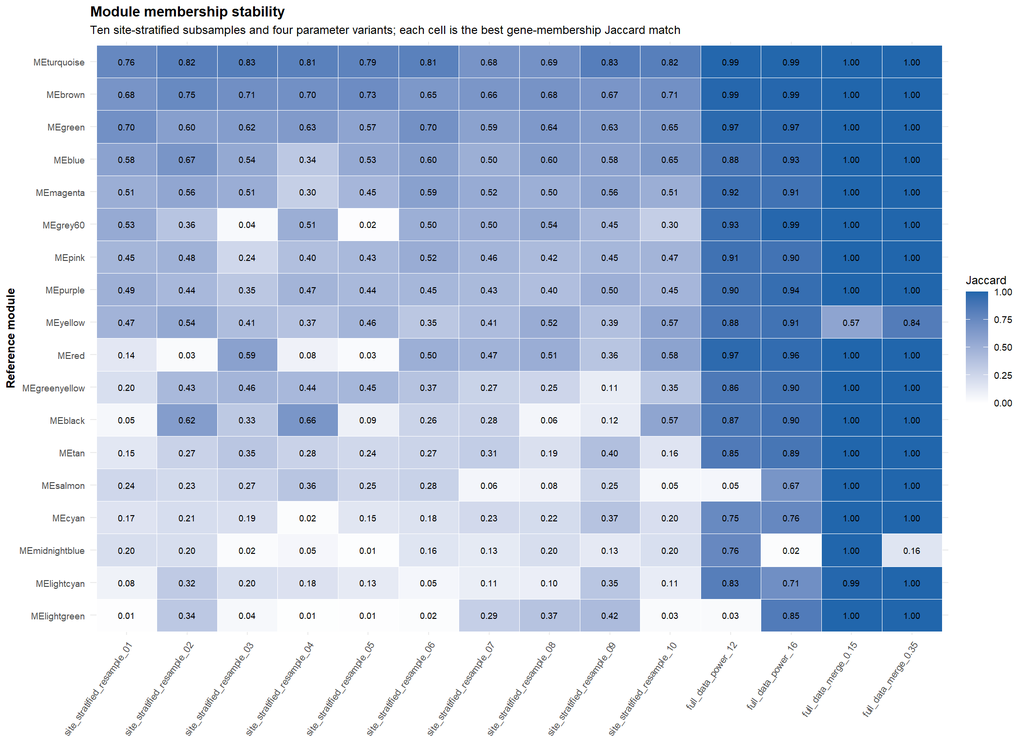

# 6 4. Primary site association of module eigengenes

The three planned contrasts are the sole primary WGCNA test family. Benjamini-Hochberg correction is applied once across the dynamically determined family of valid non-grey modules multiplied by three contrasts. The omnibus site tests are a supplementary overview and cannot independently select a module. Adjustment within each contrast is also exported as a diagnostic, not as a second inferential route.

Because the modules were derived from these same 30 expression profiles, these p-values are exploratory measures of site structure rather than validation in an independent dataset.

Omnibus site tests for assigned module eigengenes.

| module | module_label | n_libraries | n_sites | f_statistic | df_site | df_residual | p_value | eta_squared | site_q | site_fdr_supported | module_size |
| --- | --- | --- | --- | --- | --- | --- | --- | --- | --- | --- | --- |
| purple | MEpurple | 30 | 6 | 12.6135 | 5 | 24 | 0.0000 | 0.7244 | 0.0001 | TRUE | 186 |
| magenta | MEmagenta | 30 | 6 | 9.2818 | 5 | 24 | 0.0001 | 0.6591 | 0.0005 | TRUE | 231 |
| green | MEgreen | 30 | 6 | 6.2687 | 5 | 24 | 0.0007 | 0.5663 | 0.0045 | TRUE | 414 |
| red | MEred | 30 | 6 | 3.7769 | 5 | 24 | 0.0115 | 0.4404 | 0.0461 | TRUE | 337 |
| black | MEblack | 30 | 6 | 3.6904 | 5 | 24 | 0.0128 | 0.4347 | 0.0461 | TRUE | 273 |
| grey60 | MEgrey60 | 30 | 6 | 3.3757 | 5 | 24 | 0.0189 | 0.4129 | 0.0567 | FALSE | 94 |
| turquoise | MEturquoise | 30 | 6 | 3.1713 | 5 | 24 | 0.0245 | 0.3978 | 0.0630 | FALSE | 981 |
| blue | MEblue | 30 | 6 | 2.9388 | 5 | 24 | 0.0330 | 0.3797 | 0.0742 | FALSE | 950 |
| pink | MEpink | 30 | 6 | 2.3846 | 5 | 24 | 0.0684 | 0.3319 | 0.1369 | FALSE | 232 |
| brown | MEbrown | 30 | 6 | 2.2921 | 5 | 24 | 0.0775 | 0.3232 | 0.1395 | FALSE | 754 |
| greenyellow | MEgreenyellow | 30 | 6 | 1.7435 | 5 | 24 | 0.1631 | 0.2664 | 0.2668 | FALSE | 182 |
| salmon | MEsalmon | 30 | 6 | 1.5786 | 5 | 24 | 0.2040 | 0.2475 | 0.3061 | FALSE | 147 |
| lightcyan | MElightcyan | 30 | 6 | 1.2100 | 5 | 24 | 0.3346 | 0.2013 | 0.4632 | FALSE | 107 |
| yellow | MEyellow | 30 | 6 | 0.9947 | 5 | 24 | 0.4419 | 0.1717 | 0.5511 | FALSE | 674 |
| tan | MEtan | 30 | 6 | 0.9640 | 5 | 24 | 0.4593 | 0.1672 | 0.5511 | FALSE | 175 |
| lightgreen | MElightgreen | 30 | 6 | 0.4307 | 5 | 24 | 0.8227 | 0.0823 | 0.9107 | FALSE | 90 |
| cyan | MEcyan | 30 | 6 | 0.3760 | 5 | 24 | 0.8601 | 0.0726 | 0.9107 | FALSE | 131 |
| midnightblue | MEmidnightblue | 30 | 6 | 0.0710 | 5 | 24 | 0.9960 | 0.0146 | 0.9960 | FALSE | 129 |

Planned module-eigengene contrasts. The model-standardized effect uses the residual variance of the same six-site model; pairwise Hedges’ g is shown only as an archival diagnostic.

| contrast_panel | module_label | module_size | eigengene_difference | confidence_low | confidence_high | model_standardized_effect | pairwise_hedges_g_archival | p_value | q_global_planned | q_within_contrast | eigengene_direction |
| --- | --- | --- | --- | --- | --- | --- | --- | --- | --- | --- | --- |
| First WWTP transition |  |  |  |  |  |  |  |  |  |  |  |
| H3 vs H2 | MEturquoise | 981 | -0.3269 | -0.5337 | -0.1201 | -1.9986 | -1.4543 | 0.0033 | 0.0445 | 0.0588 | lower_at_numerator_site |
| First WWTP transition |  |  |  |  |  |  |  |  |  |  |  |
| H3 vs H2 | MEblack | 273 | -0.2840 | -0.4844 | -0.0837 | -1.7923 | -2.4188 | 0.0074 | 0.0665 | 0.0588 | lower_at_numerator_site |
| First WWTP transition |  |  |  |  |  |  |  |  |  |  |  |
| H3 vs H2 | MEpink | 232 | -0.2961 | -0.5139 | -0.0783 | -1.7186 | -1.8387 | 0.0098 | 0.0666 | 0.0588 | lower_at_numerator_site |
| First WWTP transition |  |  |  |  |  |  |  |  |  |  |  |
| H3 vs H2 | MEpurple | 186 | -0.1506 | -0.2905 | -0.0107 | -1.3606 | -1.4949 | 0.0360 | 0.1626 | 0.1301 | lower_at_numerator_site |
| First WWTP transition |  |  |  |  |  |  |  |  |  |  |  |
| H3 vs H2 | MEgrey60 | 94 | -0.2196 | -0.4237 | -0.0154 | -1.3596 | -0.8398 | 0.0361 | 0.1626 | 0.1301 | lower_at_numerator_site |
| First WWTP transition |  |  |  |  |  |  |  |  |  |  |  |
| H3 vs H2 | MEbrown | 754 | 0.2182 | -0.0010 | 0.4374 | 1.2583 | 0.9266 | 0.0510 | 0.1720 | 0.1529 | higher_at_numerator_site |
| First WWTP transition |  |  |  |  |  |  |  |  |  |  |  |
| H3 vs H2 | MElightcyan | 107 | 0.0980 | -0.1402 | 0.3361 | 0.5200 | 0.6702 | 0.4043 | 0.7926 | 0.9930 | higher_at_numerator_site |
| First WWTP transition |  |  |  |  |  |  |  |  |  |  |  |
| H3 vs H2 | MEgreen | 414 | -0.0584 | -0.2338 | 0.1171 | -0.4204 | -0.4656 | 0.4990 | 0.7926 | 0.9930 | lower_at_numerator_site |
| First WWTP transition |  |  |  |  |  |  |  |  |  |  |  |
| H3 vs H2 | MElightgreen | 90 | -0.0611 | -0.3164 | 0.1941 | -0.3028 | -0.2586 | 0.6256 | 0.8974 | 0.9930 | lower_at_numerator_site |
| First WWTP transition |  |  |  |  |  |  |  |  |  |  |  |
| H3 vs H2 | MEred | 337 | -0.0286 | -0.2280 | 0.1707 | -0.1816 | -2.3061 | 0.7694 | 0.9962 | 0.9930 | lower_at_numerator_site |
| First WWTP transition |  |  |  |  |  |  |  |  |  |  |  |
| H3 vs H2 | MEcyan | 131 | -0.0369 | -0.2935 | 0.2197 | -0.1816 | -0.1727 | 0.7694 | 0.9962 | 0.9930 | lower_at_numerator_site |
| First WWTP transition |  |  |  |  |  |  |  |  |  |  |  |
| H3 vs H2 | MEmagenta | 231 | -0.0209 | -0.1765 | 0.1347 | -0.1698 | -0.3033 | 0.7839 | 0.9962 | 0.9930 | lower_at_numerator_site |
| First WWTP transition |  |  |  |  |  |  |  |  |  |  |  |
| H3 vs H2 | MEblue | 950 | -0.0269 | -0.2368 | 0.1829 | -0.1623 | -0.1755 | 0.7932 | 0.9962 | 0.9930 | lower_at_numerator_site |
| First WWTP transition |  |  |  |  |  |  |  |  |  |  |  |
| H3 vs H2 | MEgreenyellow | 182 | 0.0263 | -0.2019 | 0.2546 | 0.1459 | 0.1293 | 0.8137 | 0.9966 | 0.9930 | higher_at_numerator_site |
| First WWTP transition |  |  |  |  |  |  |  |  |  |  |  |
| H3 vs H2 | MEyellow | 674 | -0.0059 | -0.2484 | 0.2366 | -0.0308 | -0.0239 | 0.9603 | 0.9966 | 0.9930 | lower_at_numerator_site |

[output cut: 78 more lines]

Primary planned-contrast evidence, formal stability gate, and supplementary omnibus overview.

| module | module_label | n_libraries | n_sites | f_statistic | df_site | df_residual | p_value | eta_squared | site_q | site_fdr_supported | module_size | max_abs_standardized_effect | max_abs_hedges_g_archival | min_planned_p | min_global_planned_q | n_global_fdr_contrasts | n_large_nominal_contrasts | global_fdr_contrasts | large_effect_contrasts | leading_contrast | leading_contrast_standardized_effect | leading_contrast_hedges_g_archival | leading_contrast_q | n_variants | median_jaccard_all | minimum_jaccard_all | median_eigengene_abs_correlation_all | median_jaccard_resampling | minimum_jaccard_resampling | … |
| --- | --- | --- | --- | --- | --- | --- | --- | --- | --- | --- | --- | --- | --- | --- | --- | --- | --- | --- | --- | --- | --- | --- | --- | --- | --- | --- | --- | --- | --- | --- |
| green | MEgreen | 30 | 6 | 6.2687 | 5 | 24 | 0.0007 | 0.5663 | 0.0045 | TRUE | 414 | 2.3343 | 1.9950 | 0.0008 | 0.0445 | 1 | 2 | HOL05_vs_HOL04 | HOL05_vs_HOL04 \| HOL06_vs_HOL01 | HOL05_vs_HOL04 | -2.3343 | -1.9719 | 0.0445 | 14 | 0.6441 | 0.5696 | 0.9985 | 0.6300 | 0.5696 | … |
| magenta | MEmagenta | 30 | 6 | 9.2818 | 5 | 24 | 0.0001 | 0.6591 | 0.0005 | TRUE | 231 | 2.0287 | 1.6729 | 0.0029 | 0.0445 | 1 | 2 | HOL05_vs_HOL04 | HOL05_vs_HOL04 \| HOL06_vs_HOL01 | HOL05_vs_HOL04 | 2.0287 | 1.4775 | 0.0445 | 14 | 0.5393 | 0.2962 | 0.9947 | 0.5085 | 0.2962 | … |
| turquoise | MEturquoise | 30 | 6 | 3.1713 | 5 | 24 | 0.0245 | 0.3978 | 0.0630 | FALSE | 981 | 1.9986 | 1.4543 | 0.0033 | 0.0445 | 1 | 2 | HOL02_vs_HOL01 | HOL02_vs_HOL01 \| HOL06_vs_HOL01 | HOL02_vs_HOL01 | -1.9986 | -1.4543 | 0.0445 | 14 | 0.8217 | 0.6760 | 0.9998 | 0.8103 | 0.6760 | … |
| red | MEred | 30 | 6 | 3.7769 | 5 | 24 | 0.0115 | 0.4404 | 0.0461 | TRUE | 337 | 2.0722 | 2.3061 | 0.0025 | 0.0445 | 1 | 1 | HOL06_vs_HOL01 | HOL06_vs_HOL01 | HOL06_vs_HOL01 | 2.0722 | 1.3457 | 0.0445 | 14 | 0.5054 | 0.0295 | 0.9636 | 0.4174 | 0.0295 | … |
| blue | MEblue | 30 | 6 | 2.9388 | 5 | 24 | 0.0330 | 0.3797 | 0.0742 | FALSE | 950 | 1.6110 | 1.8345 | 0.0147 | 0.0880 | 0 | 2 | NA | HOL05_vs_HOL04 \| HOL06_vs_HOL01 | HOL06_vs_HOL01 | 1.6110 | 1.8345 | 0.0880 | 14 | 0.5986 | 0.3394 | 0.9954 | 0.5794 | 0.3394 | … |
| black | MEblack | 30 | 6 | 3.6904 | 5 | 24 | 0.0128 | 0.4347 | 0.0461 | TRUE | 273 | 1.7923 | 2.4188 | 0.0074 | 0.0665 | 0 | 1 | NA | HOL02_vs_HOL01 | HOL02_vs_HOL01 | -1.7923 | -2.4188 | 0.0665 | 14 | 0.4498 | 0.0510 | 0.9614 | 0.2708 | 0.0510 | … |
| pink | MEpink | 30 | 6 | 2.3846 | 5 | 24 | 0.0684 | 0.3319 | 0.1369 | FALSE | 232 | 1.7186 | 1.8387 | 0.0098 | 0.0666 | 0 | 1 | NA | HOL02_vs_HOL01 | HOL02_vs_HOL01 | -1.7186 | -1.8387 | 0.0666 | 14 | 0.4629 | 0.2444 | 0.9935 | 0.4524 | 0.2444 | … |
| purple | MEpurple | 30 | 6 | 12.6135 | 5 | 24 | 0.0000 | 0.7244 | 0.0001 | TRUE | 186 | 1.3606 | 1.4949 | 0.0360 | 0.1626 | 0 | 1 | NA | HOL02_vs_HOL01 | HOL02_vs_HOL01 | -1.3606 | -1.4949 | 0.1626 | 14 | 0.4584 | 0.3468 | 0.9944 | 0.4450 | 0.3468 | … |
| grey60 | MEgrey60 | 30 | 6 | 3.3757 | 5 | 24 | 0.0189 | 0.4129 | 0.0567 | FALSE | 94 | 1.3596 | 0.8398 | 0.0361 | 0.1626 | 0 | 1 | NA | HOL02_vs_HOL01 | HOL02_vs_HOL01 | -1.3596 | -0.8398 | 0.1626 | 14 | 0.5041 | 0.0164 | 0.9908 | 0.4724 | 0.0164 | … |
| salmon | MEsalmon | 30 | 6 | 1.5786 | 5 | 24 | 0.2040 | 0.2475 | 0.3061 | FALSE | 147 | 1.3270 | 2.0132 | 0.0404 | 0.1675 | 0 | 1 | NA | HOL06_vs_HOL01 | HOL06_vs_HOL01 | 1.3270 | 2.0132 | 0.1675 | 14 | 0.2509 | 0.0487 | 0.9603 | 0.2470 | 0.0487 | … |
| greenyellow | MEgreenyellow | 30 | 6 | 1.7435 | 5 | 24 | 0.1631 | 0.2664 | 0.2668 | FALSE | 182 | 1.3059 | 1.5756 | 0.0434 | 0.1675 | 0 | 1 | NA | HOL06_vs_HOL01 | HOL06_vs_HOL01 | -1.3059 | -1.5756 | 0.1675 | 14 | 0.4367 | 0.1150 | 0.9822 | 0.3638 | 0.1150 | … |
| brown | MEbrown | 30 | 6 | 2.2921 | 5 | 24 | 0.0775 | 0.3232 | 0.1395 | FALSE | 754 | 1.2583 | 0.9266 | 0.0510 | 0.1720 | 0 | 0 | NA | NA | HOL02_vs_HOL01 | 1.2583 | 0.9266 | 0.1720 | 14 | 0.7074 | 0.6514 | 0.9994 | 0.6933 | 0.6514 | … |
| yellow | MEyellow | 30 | 6 | 0.9947 | 5 | 24 | 0.4419 | 0.1717 | 0.5511 | FALSE | 674 | 1.0431 | 0.8732 | 0.1015 | 0.3223 | 0 | 0 | NA | NA | HOL06_vs_HOL01 | 1.0431 | 0.8732 | 0.3223 | 14 | 0.4944 | 0.3469 | 0.9864 | 0.4375 | 0.3469 | … |
| tan | MEtan | 30 | 6 | 0.9640 | 5 | 24 | 0.4593 | 0.1672 | 0.5511 | FALSE | 175 | 0.9076 | 1.0211 | 0.1514 | 0.4211 | 0 | 0 | NA | NA | HOL06_vs_HOL01 | -0.9076 | -0.8695 | 0.4211 | 14 | 0.2922 | 0.1452 | 0.9759 | 0.2699 | 0.1452 | … |
| lightcyan | MElightcyan | 30 | 6 | 1.2100 | 5 | 24 | 0.3346 | 0.2013 | 0.4632 | FALSE | 107 | 0.8879 | 0.6702 | 0.1601 | 0.4211 | 0 | 0 | NA | NA | HOL05_vs_HOL04 | 0.8879 | 0.6057 | 0.4211 | 14 | 0.1890 | 0.0540 | 0.6740 | 0.1210 | 0.0540 | … |
| lightgreen | MElightgreen | 30 | 6 | 0.4307 | 5 | 24 | 0.8227 | 0.0823 | 0.9107 | FALSE | 90 | 0.6988 | 0.7078 | 0.2651 | 0.6225 | 0 | 0 | NA | NA | HOL05_vs_HOL04 | 0.6988 | 0.7078 | 0.6225 | 14 | 0.1697 | 0.0079 | 0.6533 | 0.0377 | 0.0079 | … |
| cyan | MEcyan | 30 | 6 | 0.3760 | 5 | 24 | 0.8601 | 0.0726 | 0.9107 | FALSE | 131 | 0.1910 | 0.1995 | 0.7579 | 0.9962 | 0 | 0 | NA | NA | HOL05_vs_HOL04 | -0.1910 | -0.1995 | 0.9962 | 14 | 0.2123 | 0.0198 | 0.9310 | 0.1967 | 0.0198 | … |
| midnightblue | MEmidnightblue | 30 | 6 | 0.0710 | 5 | 24 | 0.9960 | 0.0146 | 0.9960 | FALSE | 129 | 0.1002 | 0.2409 | 0.8715 | 0.9966 | 0 | 0 | NA | NA | HOL05_vs_HOL04 | 0.1002 | 0.2409 | 0.9966 | 14 | 0.1604 | 0.0134 | 0.8601 | 0.1458 | 0.0134 | … |

## 6.1 Contrast-level robustness of the retained modules

Module membership stability does not by itself demonstrate that a focal site contrast is insensitive to individual organisms. The three FDR-supported, stability-gated modules are therefore evaluated through leave-one-individual-out refitting, site-stratified bootstrap resampling, and exact two-group permutation. These are sensitivity diagnostics; the globally adjusted planned contrast remains the primary inferential test.

Contrast sensitivity of the three FDR-supported, stability-gated modules. Exact permutation p-values are descriptive and do not replace the globally adjusted planned tests.

| module_label | contrast_panel | base_eigengene_difference | base_confidence_low | base_confidence_high | model_standardized_effect | loo_direction_consistency | bootstrap_direction_consistency | bootstrap_confidence_low | bootstrap_confidence_high | exact_permutation_p | q_global_planned | contrast_robustness_pass |
| --- | --- | --- | --- | --- | --- | --- | --- | --- | --- | --- | --- | --- |
| MEturquoise | First WWTP transition |  |  |  |  |  |  |  |  |  |  |  |
| H3 vs H2 | -0.3269 | -0.5337 | -0.1201 | -1.9986 | 1 | 1.0000 | -0.5447 | -0.1085 | 0.0079 | 0.0445 | TRUE |  |
| MEgreen | Second WWTP transition |  |  |  |  |  |  |  |  |  |  |  |
| H6 vs H5 | -0.3240 | -0.4995 | -0.1485 | -2.3343 | 1 | 1.0000 | -0.4917 | -0.1620 | 0.0159 | 0.0445 | TRUE |  |
| MEmagenta | Second WWTP transition |  |  |  |  |  |  |  |  |  |  |  |
| H6 vs H5 | 0.2497 | 0.0941 | 0.4052 | 2.0287 | 1 | 0.9972 | 0.0773 | 0.4120 | 0.0397 | 0.0445 | TRUE |  |

Paper-facing module role after the planned-contrast FDR, module stability, and contrast-sensitivity gates.

| module_label | contrast_panel | eigengene_difference | confidence_low | confidence_high | model_standardized_effect | q_global_planned | stability_class | contrast_robustness_pass | paper_role |
| --- | --- | --- | --- | --- | --- | --- | --- | --- | --- |
| MEturquoise | First WWTP transition |  |  |  |  |  |  |  |  |
| H3 vs H2 | -0.3269 | -0.5337 | -0.1201 | -1.9986 | 0.0445 | high | TRUE | main_text_primary |  |
| MEgreen | Second WWTP transition |  |  |  |  |  |  |  |  |
| H6 vs H5 | -0.3240 | -0.4995 | -0.1485 | -2.3343 | 0.0445 | moderate | TRUE | main_text_primary |  |
| MEmagenta | Second WWTP transition |  |  |  |  |  |  |  |  |
| H6 vs H5 | 0.2497 | 0.0941 | 0.4052 | 2.0287 | 0.0445 | moderate | TRUE | supplementary_stable_sparse_annotation |  |

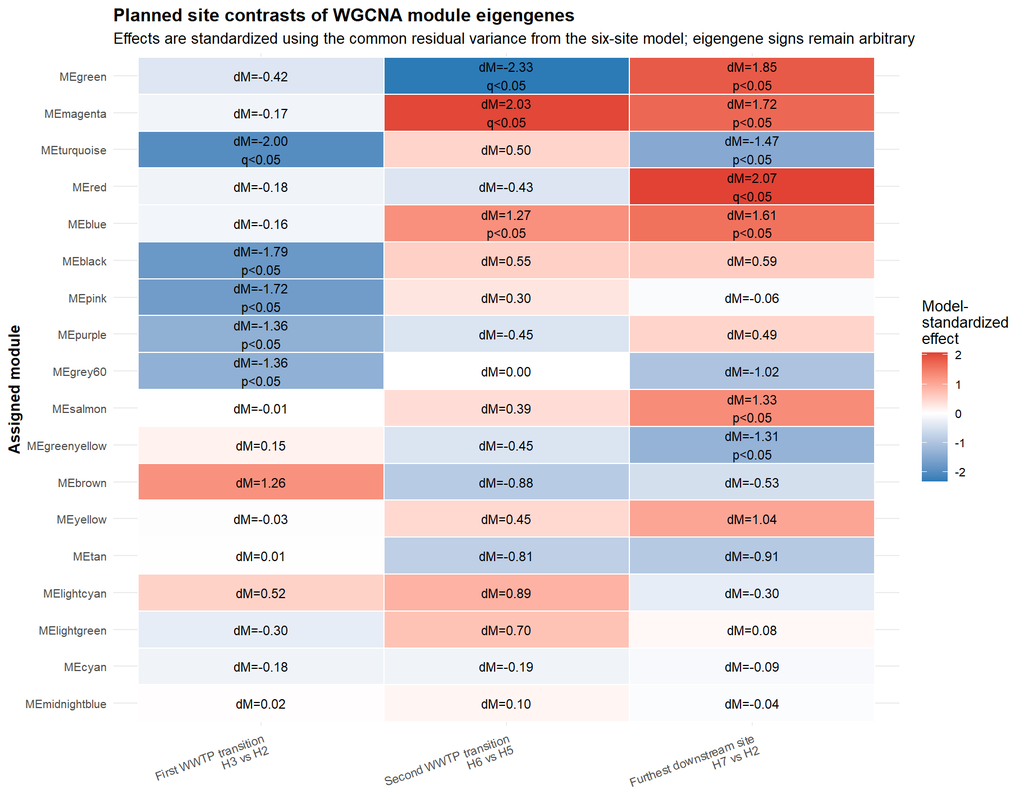

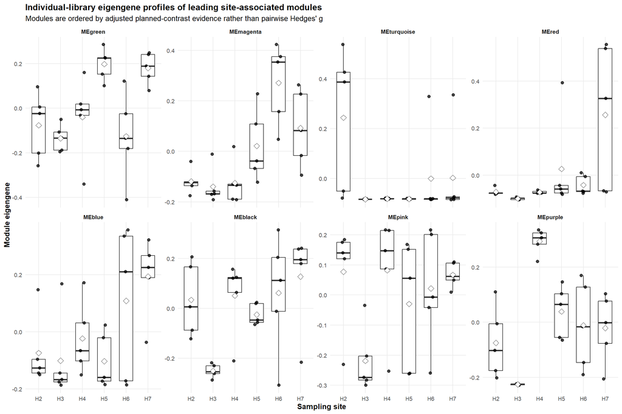

# 7 5. Differential-expression overlap in the focal contrasts

Differential-expression evidence is not used to define the WGCNA modules or to calculate the site tests. It is added afterward to determine whether genes in a site-associated module were independently supported by the focal DE analyses and whether their gene-level direction was coherent.

Differential-expression overlap of assigned modules in the three focal contrasts.

| contrast_panel | module_label | module_size | n_significant_genes | n_higher_at_numerator | n_lower_at_numerator | fraction_module_significant | median_abs_log2fc |
| --- | --- | --- | --- | --- | --- | --- | --- |
| First WWTP transition |  |  |  |  |  |  |  |
| H3 vs H2 | MEturquoise | 981 | 250 | 0 | 250 | 0.2548 | 2.2370 |
| First WWTP transition |  |  |  |  |  |  |  |
| H3 vs H2 | MEblack | 273 | 106 | 1 | 105 | 0.3883 | 4.8048 |
| First WWTP transition |  |  |  |  |  |  |  |
| H3 vs H2 | MEblue | 950 | 59 | 9 | 50 | 0.0621 | 2.5643 |
| First WWTP transition |  |  |  |  |  |  |  |
| H3 vs H2 | MEpurple | 186 | 51 | 0 | 51 | 0.2742 | 4.3547 |
| First WWTP transition |  |  |  |  |  |  |  |
| H3 vs H2 | MEpink | 232 | 43 | 0 | 43 | 0.1853 | 4.2564 |
| First WWTP transition |  |  |  |  |  |  |  |
| H3 vs H2 | MEgreen | 414 | 33 | 1 | 32 | 0.0797 | 4.2890 |
| First WWTP transition |  |  |  |  |  |  |  |
| H3 vs H2 | MEbrown | 754 | 28 | 28 | 0 | 0.0371 | 2.3276 |
| First WWTP transition |  |  |  |  |  |  |  |
| H3 vs H2 | MEyellow | 674 | 19 | 7 | 12 | 0.0282 | 2.7357 |
| First WWTP transition |  |  |  |  |  |  |  |
| H3 vs H2 | MEred | 337 | 18 | 4 | 14 | 0.0534 | 4.0694 |
| First WWTP transition |  |  |  |  |  |  |  |
| H3 vs H2 | MEmagenta | 231 | 13 | 2 | 11 | 0.0563 | 2.9805 |
| First WWTP transition |  |  |  |  |  |  |  |
| H3 vs H2 | MEcyan | 131 | 7 | 7 | 0 | 0.0534 | 3.3518 |
| First WWTP transition |  |  |  |  |  |  |  |
| H3 vs H2 | MEgrey60 | 94 | 4 | 0 | 4 | 0.0426 | 5.1522 |
| First WWTP transition |  |  |  |  |  |  |  |
| H3 vs H2 | MEtan | 175 | 4 | 4 | 0 | 0.0229 | 1.2388 |
| First WWTP transition |  |  |  |  |  |  |  |
| H3 vs H2 | MElightcyan | 107 | 1 | 1 | 0 | 0.0093 | 1.5655 |
| First WWTP transition |  |  |  |  |  |  |  |
| H3 vs H2 | MElightgreen | 90 | 1 | 1 | 0 | 0.0111 | 2.4418 |

[output cut: 68 more lines]

# 8 6. Whole-module GO enrichment

The functional target is the complete gene membership of each assigned module. The background is the same selected gene universe that was eligible to enter the WGCNA network. This avoids comparing a variance-selected module against the much larger expression-filtered transcriptome.

The primary analysis uses the EggNOG-derived gene-to-GO mapping already prepared in Step 04. GOseq is used with median gene-level transcript length as a bias proxy. Module-level FDR is calculated within each complete module enrichment, while a global FDR across all module-term tests is exported as a conservative sensitivity column. The broader Trinotate union is processed identically as a declared sensitivity analysis. GO identifiers are audited against the current local `GO.db` before either analysis; obsolete or unknown identifiers are retained in an audit table but excluded when no explicit local replacement is available.

GO annotation coverage within the 10,000-gene WGCNA universe.

| mapping_version | mapping_requested | mapping_available | n_network_genes_with_go | n_go_terms | n_gene_term_links |
| --- | --- | --- | --- | --- | --- |
| primary_eggnog | TRUE | TRUE | 994 | 8630 | 113677 |
| sensitivity_union | TRUE | TRUE | 1755 | 9301 | 121321 |

Audit of current, obsolete, and unrecognised GO identifiers before GOseq and Wang semantic reduction.

| mapping_version | n_input_gene_go_links | n_clean_gene_go_links | n_excluded_gene_go_links | n_input_genes | n_clean_genes | n_input_go_ids | n_clean_go_ids |
| --- | --- | --- | --- | --- | --- | --- | --- |
| primary_eggnog | 133895 | 113677 | 20218 | 994 | 994 | 9346 | 8630 |
| sensitivity_union | 141582 | 121321 | 20261 | 1755 | 1755 | 10030 | 9301 |

Whole-module GOseq run and annotation summary.

| module | module_label | mapping_version | n_network_genes | n_module_genes | n_network_genes_with_go | n_module_genes_with_go | n_tested_terms | n_module_fdr_terms | status |
| --- | --- | --- | --- | --- | --- | --- | --- | --- | --- |
| turquoise | MEturquoise | primary_eggnog | 10000 | 981 | 994 | 506 | 8630 | 281 | ran |
| blue | MEblue | primary_eggnog | 10000 | 950 | 994 | 43 | 8630 | 0 | ran |
| brown | MEbrown | primary_eggnog | 10000 | 754 | 994 | 52 | 8630 | 0 | ran |
| yellow | MEyellow | primary_eggnog | 10000 | 674 | 994 | 89 | 8630 | 13 | ran |
| green | MEgreen | primary_eggnog | 10000 | 414 | 994 | 77 | 8630 | 166 | ran |
| red | MEred | primary_eggnog | 10000 | 337 | 994 | 115 | 8630 | 113 | ran |
| black | MEblack | primary_eggnog | 10000 | 273 | 994 | 19 | 8630 | 0 | ran |
| pink | MEpink | primary_eggnog | 10000 | 232 | 994 | 4 | 0 | 0 | skipped_low_annotation_or_invalid_selection |
| magenta | MEmagenta | primary_eggnog | 10000 | 231 | 994 | 11 | 8630 | 0 | ran |
| purple | MEpurple | primary_eggnog | 10000 | 186 | 994 | 11 | 8630 | 0 | ran |
| greenyellow | MEgreenyellow | primary_eggnog | 10000 | 182 | 994 | 5 | 8630 | 0 | ran |
| tan | MEtan | primary_eggnog | 10000 | 175 | 994 | 2 | 0 | 0 | skipped_low_annotation_or_invalid_selection |
| salmon | MEsalmon | primary_eggnog | 10000 | 147 | 994 | 4 | 0 | 0 | skipped_low_annotation_or_invalid_selection |
| cyan | MEcyan | primary_eggnog | 10000 | 131 | 994 | 3 | 0 | 0 | skipped_low_annotation_or_invalid_selection |
| midnightblue | MEmidnightblue | primary_eggnog | 10000 | 129 | 994 | 3 | 0 | 0 | skipped_low_annotation_or_invalid_selection |
| lightcyan | MElightcyan | primary_eggnog | 10000 | 107 | 994 | 5 | 8630 | 0 | ran |
| grey60 | MEgrey60 | primary_eggnog | 10000 | 94 | 994 | 7 | 8630 | 0 | ran |
| lightgreen | MElightgreen | primary_eggnog | 10000 | 90 | 994 | 0 | 0 | 0 | skipped_low_annotation_or_invalid_selection |
| turquoise | MEturquoise | sensitivity_union | 10000 | 981 | 1755 | 631 | 9301 | 754 | ran |
| blue | MEblue | sensitivity_union | 10000 | 950 | 1755 | 87 | 9301 | 0 | ran |
| brown | MEbrown | sensitivity_union | 10000 | 754 | 1755 | 84 | 9301 | 0 | ran |
| yellow | MEyellow | sensitivity_union | 10000 | 674 | 1755 | 125 | 9301 | 17 | ran |
| green | MEgreen | sensitivity_union | 10000 | 414 | 1755 | 161 | 9301 | 150 | ran |
| red | MEred | sensitivity_union | 10000 | 337 | 1755 | 153 | 9301 | 196 | ran |
| black | MEblack | sensitivity_union | 10000 | 273 | 1755 | 137 | 9301 | 13 | ran |
| pink | MEpink | sensitivity_union | 10000 | 232 | 1755 | 11 | 9301 | 0 | ran |
| magenta | MEmagenta | sensitivity_union | 10000 | 231 | 1755 | 38 | 9301 | 0 | ran |
| purple | MEpurple | sensitivity_union | 10000 | 186 | 1755 | 37 | 9301 | 0 | ran |
| greenyellow | MEgreenyellow | sensitivity_union | 10000 | 182 | 1755 | 8 | 9301 | 0 | ran |
| tan | MEtan | sensitivity_union | 10000 | 175 | 1755 | 4 | 0 | 0 | skipped_low_annotation_or_invalid_selection |
| salmon | MEsalmon | sensitivity_union | 10000 | 147 | 1755 | 5 | 9301 | 0 | ran |
| cyan | MEcyan | sensitivity_union | 10000 | 131 | 1755 | 6 | 9301 | 0 | ran |
| midnightblue | MEmidnightblue | sensitivity_union | 10000 | 129 | 1755 | 7 | 9301 | 1 | ran |
| lightcyan | MElightcyan | sensitivity_union | 10000 | 107 | 1755 | 13 | 9301 | 0 | ran |
| grey60 | MEgrey60 | sensitivity_union | 10000 | 94 | 1755 | 22 | 9301 | 0 | ran |
| lightgreen | MElightgreen | sensitivity_union | 10000 | 90 | 1755 | 0 | 0 | 0 | skipped_low_annotation_or_invalid_selection |

Module-level comparison of primary EggNOG GO coverage and the broader Trinotate-union sensitivity mapping.

| module | module_label | n_module_genes_with_go_primary_eggnog | n_module_genes_with_go_sensitivity_union | n_tested_terms_primary_eggnog | n_tested_terms_sensitivity_union | n_module_fdr_terms_primary_eggnog | n_module_fdr_terms_sensitivity_union | status_primary_eggnog | status_sensitivity_union | delta_annotated_genes_union_minus_primary | delta_fdr_terms_union_minus_primary |
| --- | --- | --- | --- | --- | --- | --- | --- | --- | --- | --- | --- |
| turquoise | MEturquoise | 506 | 631 | 8630 | 9301 | 281 | 754 | ran | ran | 125 | 473 |
| blue | MEblue | 43 | 87 | 8630 | 9301 | 0 | 0 | ran | ran | 44 | 0 |
| brown | MEbrown | 52 | 84 | 8630 | 9301 | 0 | 0 | ran | ran | 32 | 0 |
| yellow | MEyellow | 89 | 125 | 8630 | 9301 | 13 | 17 | ran | ran | 36 | 4 |
| green | MEgreen | 77 | 161 | 8630 | 9301 | 166 | 150 | ran | ran | 84 | -16 |
| red | MEred | 115 | 153 | 8630 | 9301 | 113 | 196 | ran | ran | 38 | 83 |
| black | MEblack | 19 | 137 | 8630 | 9301 | 0 | 13 | ran | ran | 118 | 13 |
| pink | MEpink | 4 | 11 | 0 | 9301 | 0 | 0 | skipped_low_annotation_or_invalid_selection | ran | 7 | 0 |
| magenta | MEmagenta | 11 | 38 | 8630 | 9301 | 0 | 0 | ran | ran | 27 | 0 |
| purple | MEpurple | 11 | 37 | 8630 | 9301 | 0 | 0 | ran | ran | 26 | 0 |
| greenyellow | MEgreenyellow | 5 | 8 | 8630 | 9301 | 0 | 0 | ran | ran | 3 | 0 |
| tan | MEtan | 2 | 4 | 0 | 0 | 0 | 0 | skipped_low_annotation_or_invalid_selection | skipped_low_annotation_or_invalid_selection | 2 | 0 |
| salmon | MEsalmon | 4 | 5 | 0 | 9301 | 0 | 0 | skipped_low_annotation_or_invalid_selection | ran | 1 | 0 |
| cyan | MEcyan | 3 | 6 | 0 | 9301 | 0 | 0 | skipped_low_annotation_or_invalid_selection | ran | 3 | 0 |
| midnightblue | MEmidnightblue | 3 | 7 | 0 | 9301 | 0 | 1 | skipped_low_annotation_or_invalid_selection | ran | 4 | 1 |
| lightcyan | MElightcyan | 5 | 13 | 8630 | 9301 | 0 | 0 | ran | ran | 8 | 0 |
| grey60 | MEgrey60 | 7 | 22 | 8630 | 9301 | 0 | 0 | ran | ran | 15 | 0 |
| lightgreen | MElightgreen | 0 | 0 | 0 | 0 | 0 | 0 | skipped_low_annotation_or_invalid_selection | skipped_low_annotation_or_invalid_selection | 0 | 0 |

Supportive whole-module EggNOG KEGG enrichment summary.

| module | module_label | mapping_version | n_network_genes | n_module_genes | n_network_genes_with_go | n_module_genes_with_go | n_tested_terms | n_module_fdr_terms | status |
| --- | --- | --- | --- | --- | --- | --- | --- | --- | --- |
| turquoise | MEturquoise | primary_eggnog_kegg | 10000 | 981 | 823 | 412 | 329 | 0 | ran |
| blue | MEblue | primary_eggnog_kegg | 10000 | 950 | 823 | 32 | 329 | 0 | ran |
| brown | MEbrown | primary_eggnog_kegg | 10000 | 754 | 823 | 32 | 329 | 0 | ran |
| yellow | MEyellow | primary_eggnog_kegg | 10000 | 674 | 823 | 38 | 329 | 7 | ran |
| green | MEgreen | primary_eggnog_kegg | 10000 | 414 | 823 | 73 | 329 | 9 | ran |
| red | MEred | primary_eggnog_kegg | 10000 | 337 | 823 | 114 | 329 | 1 | ran |
| black | MEblack | primary_eggnog_kegg | 10000 | 273 | 823 | 42 | 329 | 9 | ran |
| pink | MEpink | primary_eggnog_kegg | 10000 | 232 | 823 | 2 | 0 | 0 | skipped_low_annotation_or_invalid_selection |
| magenta | MEmagenta | primary_eggnog_kegg | 10000 | 231 | 823 | 14 | 329 | 0 | ran |
| purple | MEpurple | primary_eggnog_kegg | 10000 | 186 | 823 | 17 | 329 | 0 | ran |
| greenyellow | MEgreenyellow | primary_eggnog_kegg | 10000 | 182 | 823 | 2 | 0 | 0 | skipped_low_annotation_or_invalid_selection |
| tan | MEtan | primary_eggnog_kegg | 10000 | 175 | 823 | 0 | 0 | 0 | skipped_low_annotation_or_invalid_selection |
| salmon | MEsalmon | primary_eggnog_kegg | 10000 | 147 | 823 | 5 | 329 | 0 | ran |
| cyan | MEcyan | primary_eggnog_kegg | 10000 | 131 | 823 | 1 | 0 | 0 | skipped_low_annotation_or_invalid_selection |
| midnightblue | MEmidnightblue | primary_eggnog_kegg | 10000 | 129 | 823 | 1 | 0 | 0 | skipped_low_annotation_or_invalid_selection |
| lightcyan | MElightcyan | primary_eggnog_kegg | 10000 | 107 | 823 | 2 | 0 | 0 | skipped_low_annotation_or_invalid_selection |
| grey60 | MEgrey60 | primary_eggnog_kegg | 10000 | 94 | 823 | 3 | 0 | 0 | skipped_low_annotation_or_invalid_selection |
| lightgreen | MElightgreen | primary_eggnog_kegg | 10000 | 90 | 823 | 0 | 0 | 0 | skipped_low_annotation_or_invalid_selection |

Functional interpretation of complete assigned modules.

| module | module_label | mapping_version | n_network_genes | n_module_genes | n_network_genes_with_go | n_module_genes_with_go | n_tested_terms | n_module_fdr_terms | status | n_supported_themes | n_significant_go_terms | leading_theme | supported_themes | leading_terms | whole_module_functional_support |
| --- | --- | --- | --- | --- | --- | --- | --- | --- | --- | --- | --- | --- | --- | --- | --- |
| turquoise | MEturquoise | primary_eggnog | 10000 | 981 | 994 | 506 | 8630 | 281 | ran | 11 | 281 | Other or unresolved function | Cell signalling and regulation \| Cell stress, turnover, and catabolism \| Development, adhesion, and cytoskeletal remodelling \| Energy and primary metabolism \| Immune, inflammatory, and hemostatic … | active transmembrane transporter activity \| acyltransferase activity \| amide transport \| binding \| biological regulation \| amide metabolic process \| generation of precursor metabolites and energ… | whole_module_GO_support |
| blue | MEblue | primary_eggnog | 10000 | 950 | 994 | 43 | 8630 | 0 | ran | 0 | 0 | NA | NA | NA | no_module_FDR_terms |
| brown | MEbrown | primary_eggnog | 10000 | 754 | 994 | 52 | 8630 | 0 | ran | 0 | 0 | NA | NA | NA | no_module_FDR_terms |
| yellow | MEyellow | primary_eggnog | 10000 | 674 | 994 | 89 | 8630 | 13 | ran | 3 | 13 | Chitin and carbohydrate remodelling | Chitin and carbohydrate remodelling \| Development, adhesion, and cytoskeletal remodelling \| Other or unresolved function | anatomical structure development \| body morphogenesis \| chitin-based cuticle development \| cuticle development \| developmental process \| extracellular region \| multicellular organismal process \… | whole_module_GO_support |
| green | MEgreen | primary_eggnog | 10000 | 414 | 994 | 77 | 8630 | 166 | ran | 11 | 166 | Other or unresolved function | Cell signalling and regulation \| Cell stress, turnover, and catabolism \| Chitin and carbohydrate remodelling \| Development, adhesion, and cytoskeletal remodelling \| Energy and primary metabolism \… | alcohol biosynthetic process \| alpha-amylase activity \| ammonium ion metabolic process \| amylase activity \| cell projection organization \| anatomical structure morphogenesis \| axon development \… | whole_module_GO_support |
| red | MEred | primary_eggnog | 10000 | 337 | 994 | 115 | 8630 | 113 | ran | 5 | 113 | Other or unresolved function | Cell stress, turnover, and catabolism \| Energy and primary metabolism \| Other or unresolved function \| Proteostasis, translation, and RNA processing \| Transport and intracellular trafficking | amide biosynthetic process \| amide transport \| biological regulation \| biosynthetic process \| cellular biosynthetic process \| amide metabolic process \| metabolic process \| mRNA metabolic proces… | whole_module_GO_support |
| black | MEblack | primary_eggnog | 10000 | 273 | 994 | 19 | 8630 | 0 | ran | 0 | 0 | NA | NA | NA | no_module_FDR_terms |
| pink | MEpink | primary_eggnog | 10000 | 232 | 994 | 4 | 0 | 0 | skipped_low_annotation_or_invalid_selection | 0 | 0 | NA | NA | NA | insufficient_module_annotation |
| magenta | MEmagenta | primary_eggnog | 10000 | 231 | 994 | 11 | 8630 | 0 | ran | 0 | 0 | NA | NA | NA | no_module_FDR_terms |
| purple | MEpurple | primary_eggnog | 10000 | 186 | 994 | 11 | 8630 | 0 | ran | 0 | 0 | NA | NA | NA | no_module_FDR_terms |
| greenyellow | MEgreenyellow | primary_eggnog | 10000 | 182 | 994 | 5 | 8630 | 0 | ran | 0 | 0 | NA | NA | NA | no_module_FDR_terms |
| tan | MEtan | primary_eggnog | 10000 | 175 | 994 | 2 | 0 | 0 | skipped_low_annotation_or_invalid_selection | 0 | 0 | NA | NA | NA | insufficient_module_annotation |
| salmon | MEsalmon | primary_eggnog | 10000 | 147 | 994 | 4 | 0 | 0 | skipped_low_annotation_or_invalid_selection | 0 | 0 | NA | NA | NA | insufficient_module_annotation |
| cyan | MEcyan | primary_eggnog | 10000 | 131 | 994 | 3 | 0 | 0 | skipped_low_annotation_or_invalid_selection | 0 | 0 | NA | NA | NA | insufficient_module_annotation |
| midnightblue | MEmidnightblue | primary_eggnog | 10000 | 129 | 994 | 3 | 0 | 0 | skipped_low_annotation_or_invalid_selection | 0 | 0 | NA | NA | NA | insufficient_module_annotation |
| lightcyan | MElightcyan | primary_eggnog | 10000 | 107 | 994 | 5 | 8630 | 0 | ran | 0 | 0 | NA | NA | NA | no_module_FDR_terms |
| grey60 | MEgrey60 | primary_eggnog | 10000 | 94 | 994 | 7 | 8630 | 0 | ran | 0 | 0 | NA | NA | NA | no_module_FDR_terms |
| lightgreen | MElightgreen | primary_eggnog | 10000 | 90 | 994 | 0 | 0 | 0 | skipped_low_annotation_or_invalid_selection | 0 | 0 | NA | NA | NA | insufficient_module_annotation |

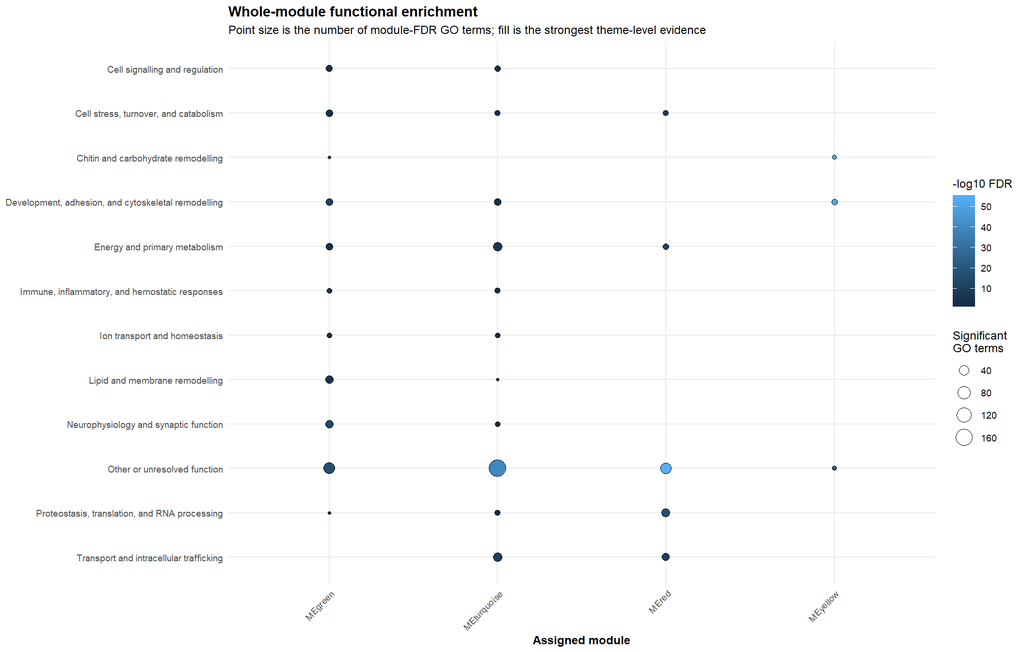

## 8.1 Ontology-specific Wang semantic reduction

RRvGO-style reduction is applied only after GOseq significance testing. BP, MF, and CC are reduced separately using Wang similarity from the current GO graph. The similarity calculation is topology based and therefore does not import annotation frequencies from an unrelated organism `OrgDb`. The clustering and representative-term structure follows RRvGO: terms are hierarchically clustered from their semantic-similarity matrix and the term with the largest `-log10(module-wide FDR)` score represents each cluster. This step reduces redundancy; it is not a new significance test or module-selection route.

Ontology-specific Wang semantic-reduction summary for primary EggNOG whole-module GO enrichment.

| module | module_label | n_rrvgo_clusters_BP | n_rrvgo_clusters_CC | n_rrvgo_clusters_MF | leading_rrvgo_terms_BP | leading_rrvgo_terms_CC | leading_rrvgo_terms_MF |
| --- | --- | --- | --- | --- | --- | --- | --- |
| green | MEgreen | 35 | 2 | 4 | cell projection morphogenesis \| cell projection organization \| cell recognition \| cobalamin metabolic process \| collagen catabolic process \| diol biosynthetic process | extracellular space \| lysosomal lumen | fucose binding \| hydrolase activity, hydrolyzing O-glycosyl compounds \| peptidase activity \| scavenger receptor binding |
| red | MEred | 14 | 6 | 2 | amide transport \| biosynthetic process \| cellular response to endogenous stimulus \| establishment of protein localization \| gene expression \| intracellular protein transport | cytoplasmic side of rough endoplasmic reticulum membrane \| intracellular anatomical structure \| membrane-enclosed lumen \| nucleus \| ribonucleoprotein complex \| ribosome | RNA binding \| structural constituent of ribosome |
| turquoise | MEturquoise | 37 | 9 | 9 | animal organ development \| cell-cell signaling \| cellular component biogenesis \| cellular localization \| cellular metabolic process \| cellular process | endomembrane system \| intracellular anatomical structure \| intracellular membrane-bounded organelle \| membrane-bounded organelle \| membrane-enclosed lumen \| organelle | active transmembrane transporter activity \| binding \| enzyme binding \| molecular_function \| nucleoside binding \| nucleotide binding |
| yellow | MEyellow | 2 | 2 | 4 | anatomical structure development \| chitin-based cuticle development | extracellular matrix \| extracellular region | structural constituent of chitin-based cuticle \| structural constituent of chitin-based larval cuticle \| structural constituent of cuticle \| structural molecule activity |

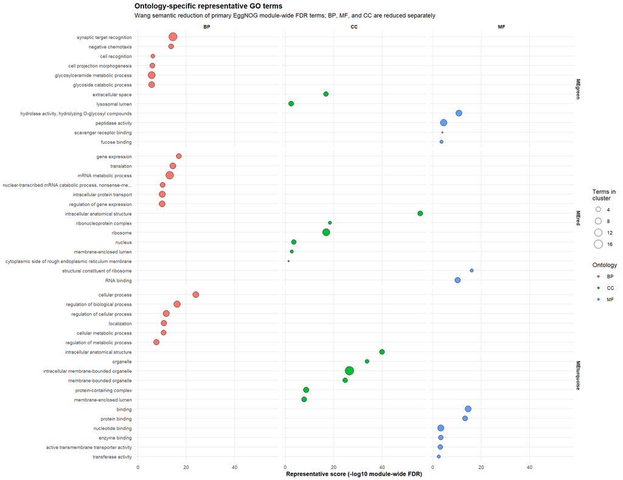

# 9 7. Site-first module selection and detailed functional dossiers

The primary paper-facing gate requires both a globally FDR-supported planned contrast and acceptable module stability. Whole-module functional enrichment, DEG overlap, and interpretable hubs determine whether a gate-passing module has enough biological content for detailed interpretation. When a contrast has no FDR-supported module, its two leading absolute effects remain visible as an explicitly exploratory ranking; neither the omnibus tests nor chemistry can promote those modules into the primary family.

Site-first modules retained for detailed functional inspection; effect-size ranking uses the six-site model-standardized contrast.

| module_label | module_size | site_evidence_status | min_global_planned_q | max_abs_standardized_effect | leading_contrast | leading_contrast_standardized_effect | stability_class | median_jaccard_resampling | minimum_jaccard_all | stability_gate_pass | n_significant_go_terms | leading_theme | leading_rrvgo_terms_BP | leading_rrvgo_terms_MF | leading_rrvgo_terms_CC | site_function_status |
| --- | --- | --- | --- | --- | --- | --- | --- | --- | --- | --- | --- | --- | --- | --- | --- | --- |
| MEgreen | 414 | planned_contrast_FDR | 0.0445 | 2.3343 | HOL05_vs_HOL04 | -2.3343 | moderate | 0.6300 | 0.5696 | TRUE | 166 | Other or unresolved function | cell projection morphogenesis \| cell projection organization \| cell recognition \| cobalamin metabolic process \| collagen catabolic process \| diol biosynthetic process | fucose binding \| hydrolase activity, hydrolyzing O-glycosyl compounds \| peptidase activity \| scavenger receptor binding | extracellular space \| lysosomal lumen | primary_FDR_stable_and_whole_module_function |
| MEturquoise | 981 | planned_contrast_FDR | 0.0445 | 1.9986 | HOL02_vs_HOL01 | -1.9986 | high | 0.8103 | 0.6760 | TRUE | 281 | Other or unresolved function | animal organ development \| cell-cell signaling \| cellular component biogenesis \| cellular localization \| cellular metabolic process \| cellular process | active transmembrane transporter activity \| binding \| enzyme binding \| molecular_function \| nucleoside binding \| nucleotide binding | endomembrane system \| intracellular anatomical structure \| intracellular membrane-bounded organelle \| membrane-bounded organelle \| membrane-enclosed lumen \| organelle | primary_FDR_stable_and_whole_module_function |
| MEmagenta | 231 | planned_contrast_FDR | 0.0445 | 2.0287 | HOL05_vs_HOL04 | 2.0287 | moderate | 0.5085 | 0.2962 | TRUE | 0 | NA | NA | NA | NA | primary_FDR_stable_without_GO_FDR |
| MEred | 337 | planned_contrast_FDR | 0.0445 | 2.0722 | HOL06_vs_HOL01 | 2.0722 | low | 0.4174 | 0.0295 | FALSE | 113 | Other or unresolved function | amide transport \| biosynthetic process \| cellular response to endogenous stimulus \| establishment of protein localization \| gene expression \| intracellular protein transport | RNA binding \| structural constituent of ribosome | cytoplasmic side of rough endoplasmic reticulum membrane \| intracellular anatomical structure \| membrane-enclosed lumen \| nucleus \| ribonucleoprotein complex \| ribosome | primary_site_FDR_but_stability_gate_failed |
| MEblack | 273 | exploratory_large_nominal_contrast_effect | 0.0665 | 1.7923 | HOL02_vs_HOL01 | -1.7923 | low | 0.2708 | 0.0510 | FALSE | 0 | NA | NA | NA | NA | exploratory_site_pattern |
| MEpink | 232 | exploratory_large_nominal_contrast_effect | 0.0666 | 1.7186 | HOL02_vs_HOL01 | -1.7186 | low | 0.4524 | 0.2444 | FALSE | 0 | NA | NA | NA | NA | exploratory_site_pattern |
| MEblue | 950 | exploratory_large_nominal_contrast_effect | 0.0880 | 1.6110 | HOL06_vs_HOL01 | 1.6110 | moderate | 0.5794 | 0.3394 | TRUE | 0 | NA | NA | NA | NA | exploratory_site_pattern |
| MEpurple | 186 | exploratory_large_nominal_contrast_effect | 0.1626 | 1.3606 | HOL02_vs_HOL01 | -1.3606 | low | 0.4450 | 0.3468 | FALSE | 0 | NA | NA | NA | NA | exploratory_site_pattern |

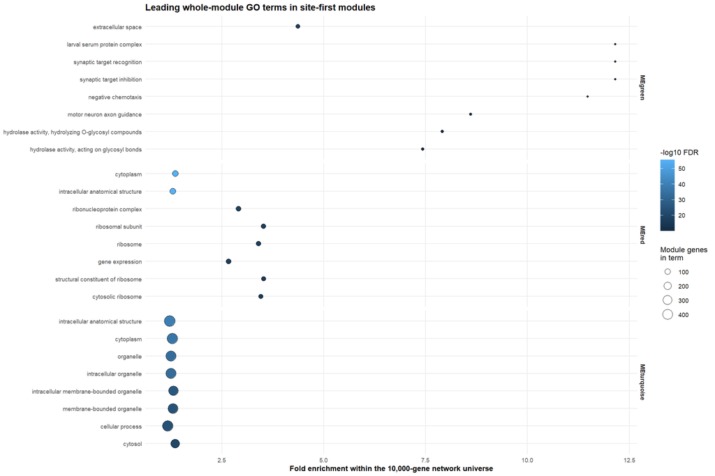

## 9.1 Supportive whole-module KEGG enrichment

KEGG pathways are tested as a separate supportive family using the EggNOG gene-to-pathway mapping prepared in Step 04, the same selected WGCNA background, and the same length-bias correction. KEGG does not determine module selection and is not subjected to GO semantic reduction. Local pathway identifiers are retained verbatim where no versioned local pathway-name catalogue is available.

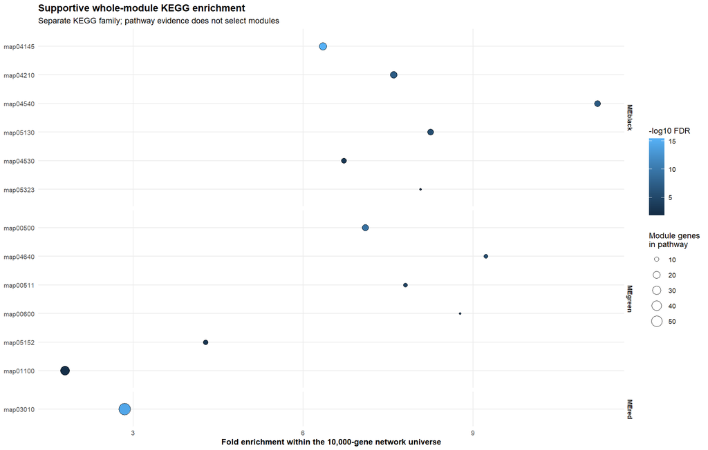

# 10 8. Hub genes, DEG support, and enriched-term traceback

Hub status describes strong membership in the module’s dominant expression profile. It does not show that a hub gene responds directly to a chemical or MoA. The gene dossier therefore keeps module connectivity, focal DEG support, and whole-module functional traceback as separate evidence columns.

Highly connected genes in the site-first modules, with independent DEG and functional traceback.

| module_label | module_hub_rank | gene_id | best_gene_label | module_kME_signed | module_kME_abs | focal_deg_contrasts | max_abs_focal_log2fc | enriched_module_themes | n_enriched_module_terms |
| --- | --- | --- | --- | --- | --- | --- | --- | --- | --- |
| MEblack | 1 | TRINITY_DN5590_c0_g1 | H2B | 0.9399 | 0.9399 | HOL02_vs_HOL01 | 4.0004 | NA | NA |
| MEblack | 2 | TRINITY_DN2169_c0_g2 | CATL2 | 0.9215 | 0.9215 | HOL02_vs_HOL01 | 6.0470 | NA | NA |
| MEblack | 3 | TRINITY_DN24094_c0_g1 | ycnE | 0.9210 | 0.9210 | NA | NA | NA | NA |
| MEblack | 4 | TRINITY_DN31642_c0_g1 | TRINITY_DN31642_c0_g1 | 0.9192 | 0.9192 | HOL02_vs_HOL01 | 5.2805 | NA | NA |
| MEblack | 5 | TRINITY_DN23587_c1_g1 | UBC | 0.9036 | 0.9036 | HOL02_vs_HOL01 | 4.6747 | NA | NA |
| MEblack | 6 | TRINITY_DN6792_c0_g1 | CATL2 | 0.9014 | 0.9014 | NA | NA | NA | NA |
| MEblack | 7 | TRINITY_DN6582_c0_g1 | TRINITY_DN6582_c0_g1 | 0.8980 | 0.8980 | HOL02_vs_HOL01 | 5.1207 | NA | NA |
| MEblack | 8 | TRINITY_DN916_c0_g2 | H2B | 0.8911 | 0.8911 | HOL02_vs_HOL01 | 4.7326 | NA | NA |
| MEblack | 9 | TRINITY_DN5466_c0_g2 | CATL | 0.8828 | 0.8828 | NA | NA | NA | NA |
| MEblack | 10 | TRINITY_DN129248_c0_g1 | TBB | 0.8807 | 0.8807 | NA | NA | NA | NA |
| MEblack | 11 | TRINITY_DN272_c5_g1 | TBA | 0.8761 | 0.8761 | NA | NA | NA | NA |
| MEblack | 12 | TRINITY_DN1227_c0_g1 | H2A1 | 0.8742 | 0.8742 | HOL02_vs_HOL01 | 3.4821 | NA | NA |
| MEblack | 13 | TRINITY_DN14313_c0_g1 | TRINITY_DN14313_c0_g1 | 0.8735 | 0.8735 | HOL02_vs_HOL01 | 4.2895 | NA | NA |
| MEblack | 14 | TRINITY_DN6272_c4_g1 | TBB1 | 0.8733 | 0.8733 | HOL02_vs_HOL01 | 6.3180 | NA | NA |
| MEblack | 15 | TRINITY_DN16679_c0_g1 | CETN2 | 0.8667 | 0.8667 | HOL02_vs_HOL01 \| HOL05_vs_HOL04 | 5.4510 | NA | NA |
| MEblue | 1 | TRINITY_DN3843_c1_g1 | APOB | 0.9821 | 0.9821 | NA | NA | NA | NA |
| MEblue | 2 | TRINITY_DN12000_c0_g1 | TRINITY_DN12000_c0_g1 | 0.9810 | 0.9810 | NA | NA | NA | NA |
| MEblue | 3 | TRINITY_DN19265_c0_g1 | TRINITY_DN19265_c0_g1 | 0.9804 | 0.9804 | HOL05_vs_HOL04 | 4.7414 | NA | NA |
| MEblue | 4 | TRINITY_DN14552_c0_g2 | TRINITY_DN14552_c0_g2 | 0.9804 | 0.9804 | NA | NA | NA | NA |
| MEblue | 5 | TRINITY_DN156169_c0_g1 | TRINITY_DN156169_c0_g1 | 0.9797 | 0.9797 | HOL05_vs_HOL04 | 3.5791 | NA | NA |
| MEblue | 6 | TRINITY_DN11466_c0_g1 | DM4/DM12 family | 0.9783 | 0.9783 | NA | NA | NA | NA |
| MEblue | 7 | TRINITY_DN2078_c6_g1 | proline rich protein | 0.9759 | 0.9759 | HOL05_vs_HOL04 | 4.8619 | NA | NA |
| MEblue | 8 | TRINITY_DN4666_c1_g2 | TRINITY_DN4666_c1_g2 | 0.9755 | 0.9755 | HOL05_vs_HOL04 | 4.2141 | NA | NA |
| MEblue | 9 | TRINITY_DN5495_c0_g1 | TRY7 | 0.9739 | 0.9739 | HOL05_vs_HOL04 | 4.2284 | NA | NA |
| MEblue | 10 | TRINITY_DN9208_c0_g1 | TRINITY_DN9208_c0_g1 | 0.9738 | 0.9738 | NA | NA | NA | NA |
| MEblue | 11 | TRINITY_DN769_c1_g1 | Hexo1 | 0.9718 | 0.9718 | NA | NA | NA | NA |
| MEblue | 12 | TRINITY_DN7284_c0_g1 | TRINITY_DN7284_c0_g1 | 0.9704 | 0.9704 | NA | NA | NA | NA |
| MEblue | 13 | TRINITY_DN4392_c0_g1 | TRINITY_DN4392_c0_g1 | 0.9692 | 0.9692 | HOL05_vs_HOL04 | 4.8128 | NA | NA |
| MEblue | 14 | TRINITY_DN344_c0_g1 | Bzd | 0.9687 | 0.9687 | HOL05_vs_HOL04 | 4.2467 | NA | NA |
| MEblue | 15 | TRINITY_DN14336_c0_g2 | TRINITY_DN14336_c0_g2 | 0.9683 | 0.9683 | HOL05_vs_HOL04 | 3.6292 | NA | NA |

[output cut: 90 more lines]

# 11 9. Chemistry overlay after site and function selection

Total predicted mixture pressure is retained as the primary quantitative chemistry context. The five direct MoA-specific summed-TU profiles are secondary exploratory descriptors. They do not determine which modules enter the site-first functional dossiers.

Availability and analytical role of the chemistry overlay.

| network_source | chemistry_inputs_available | total_pressure_associations_computed | moa_associations_computed | moa_redundancy_diagnostics_computed | chemistry_used_for_module_selection |
| --- | --- | --- | --- | --- | --- |
| Step 07 selected G10000 network | TRUE | TRUE | TRUE | TRUE | FALSE |

Total-pressure and leading MoA context for modules selected independently by site and functional evidence.

| module | module_label | site_evidence_status | leading_contrast | leading_contrast_standardized_effect | leading_theme | n_significant_go_terms | log10_STU_r | log10_STU_p | log10_STU_q | leading_moa | leading_moa_r | leading_moa_p | leading_moa_q | leading_moa_loso_sign_consistency | leading_moa_profile_specificity | chemistry_interpretation_scope |
| --- | --- | --- | --- | --- | --- | --- | --- | --- | --- | --- | --- | --- | --- | --- | --- | --- |
| green | MEgreen | planned_contrast_FDR | HOL05_vs_HOL04 | -2.3343 | Other or unresolved function | 166 | -0.0520 | 0.9221 | 0.9764 | Sterol biosynthesis inhibition | -0.5116 | 0.2996 | 0.8475 | 1.0000 | comparatively_distinct_profile | Chemistry is a six-site contextual alignment and does not identify the causal driver of the module or of individual module genes. |
| turquoise | MEturquoise | planned_contrast_FDR | HOL02_vs_HOL01 | -1.9986 | Other or unresolved function | 281 | -0.7503 | 0.0857 | 0.9210 | Endocrine | -0.9163 | 0.0102 | 0.3581 | 1.0000 | partly_redundant_profile | Chemistry is a six-site contextual alignment and does not identify the causal driver of the module or of individual module genes. |
| magenta | MEmagenta | planned_contrast_FDR | HOL05_vs_HOL04 | 2.0287 | NA | 0 | 0.5149 | 0.2959 | 0.9210 | Antiinflammatory | 0.7797 | 0.0674 | 0.8475 | 1.0000 | closely_tracks_another_primary_moa | Chemistry is a six-site contextual alignment and does not identify the causal driver of the module or of individual module genes. |
| red | MEred | planned_contrast_FDR | HOL06_vs_HOL01 | 2.0722 | Other or unresolved function | 113 | 0.1947 | 0.7117 | 0.9210 | Sterol biosynthesis inhibition | -0.5809 | 0.2267 | 0.8475 | 1.0000 | comparatively_distinct_profile | Chemistry is a six-site contextual alignment and does not identify the causal driver of the module or of individual module genes. |
| black | MEblack | exploratory_large_nominal_contrast_effect | HOL02_vs_HOL01 | -1.7923 | NA | 0 | -0.2215 | 0.6731 | 0.9210 | Sterol biosynthesis inhibition | -0.9425 | 0.0049 | 0.3581 | 1.0000 | comparatively_distinct_profile | Chemistry is a six-site contextual alignment and does not identify the causal driver of the module or of individual module genes. |
| pink | MEpink | exploratory_large_nominal_contrast_effect | HOL02_vs_HOL01 | -1.7186 | NA | 0 | -0.4657 | 0.3519 | 0.9210 | Sterol biosynthesis inhibition | -0.8287 | 0.0415 | 0.8475 | 0.8333 | comparatively_distinct_profile | Chemistry is a six-site contextual alignment and does not identify the causal driver of the module or of individual module genes. |
| blue | MEblue | exploratory_large_nominal_contrast_effect | HOL06_vs_HOL01 | 1.6110 | NA | 0 | 0.4305 | 0.3941 | 0.9210 | Sterol biosynthesis inhibition | -0.6646 | 0.1499 | 0.8475 | 1.0000 | comparatively_distinct_profile | Chemistry is a six-site contextual alignment and does not identify the causal driver of the module or of individual module genes. |
| purple | MEpurple | exploratory_large_nominal_contrast_effect | HOL02_vs_HOL01 | -1.3606 | NA | 0 | -0.1380 | 0.7943 | 0.9532 | Sterol biosynthesis inhibition | -0.5252 | 0.2846 | 0.8475 | 0.8333 | comparatively_distinct_profile | Chemistry is a six-site contextual alignment and does not identify the causal driver of the module or of individual module genes. |

# 12 10. Integrated site-first module dossiers

Integrated site-first module dossiers.

| module_label | module_size | evidence_tier | site_evidence_status | min_global_planned_q | leading_contrast | leading_contrast_standardized_effect | stability_class | median_jaccard_resampling | minimum_jaccard_all | max_focal_deg_count | n_significant_go_terms | leading_theme | leading_rrvgo_terms_BP | leading_rrvgo_terms_MF | leading_rrvgo_terms_CC | n_significant_kegg_pathways | leading_kegg_pathways | top_hub_gene_labels | log10_STU_r | leading_moa | leading_moa_r | leading_moa_profile_specificity |
| --- | --- | --- | --- | --- | --- | --- | --- | --- | --- | --- | --- | --- | --- | --- | --- | --- | --- | --- | --- | --- | --- | --- |
| MEgreen | 414 | primary_site_FDR_stability_function_and_DEG | planned_contrast_FDR | 0.0445 | HOL05_vs_HOL04 | -2.3343 | moderate | 0.6300 | 0.5696 | 51 | 166 | Other or unresolved function | cell projection morphogenesis \| cell projection organization \| cell recognition \| cobalamin metabolic process \| collagen catabolic process \| diol biosynthetic process | fucose binding \| hydrolase activity, hydrolyzing O-glycosyl compounds \| peptidase activity \| scavenger receptor binding | extracellular space \| lysosomal lumen | 9 | map00500 \| map00511 \| map00600 \| map01100 \| map04614 \| map04640 | AMY2A \| BGBP \| CBPA2 \| Chitin-binding domain type 2 \| GBA \| GNBPB1 \| GUN4 \| NPL11 | -0.0520 | Sterol biosynthesis inhibition | -0.5116 | comparatively_distinct_profile |
| MEturquoise | 981 | primary_site_FDR_stability_function_and_DEG | planned_contrast_FDR | 0.0445 | HOL02_vs_HOL01 | -1.9986 | high | 0.8103 | 0.6760 | 250 | 281 | Other or unresolved function | animal organ development \| cell-cell signaling \| cellular component biogenesis \| cellular localization \| cellular metabolic process \| cellular process | active transmembrane transporter activity \| binding \| enzyme binding \| molecular_function \| nucleoside binding \| nucleotide binding | endomembrane system \| intracellular anatomical structure \| intracellular membrane-bounded organelle \| membrane-bounded organelle \| membrane-enclosed lumen \| organelle | NA | NA | AKR1B1 \| ARCA \| CALM \| CML2 \| GSTA4 \| HPGDS \| PMP3 \| SLC1A1 | -0.7503 | Endocrine | -0.9163 | partly_redundant_profile |
| MEmagenta | 231 | primary_site_FDR_and_stability_only | planned_contrast_FDR | 0.0445 | HOL05_vs_HOL04 | 2.0287 | moderate | 0.5085 | 0.2962 | 44 | 0 | NA | NA | NA | NA | NA | NA | chiA \| ENO2 \| F11 \| TRINITY_DN11109_c0_g1 \| TRINITY_DN11216_c0_g1 \| TRINITY_DN1243_c0_g1 \| TRINITY_DN13059_c0_g1 \| TRINITY_DN1530_c0_g1 | 0.5149 | Antiinflammatory | 0.7797 | closely_tracks_another_primary_moa |
| MEred | 337 | site_FDR_but_stability_failed | planned_contrast_FDR | 0.0445 | HOL06_vs_HOL01 | 2.0722 | low | 0.4174 | 0.0295 | 165 | 113 | Other or unresolved function | amide transport \| biosynthetic process \| cellular response to endogenous stimulus \| establishment of protein localization \| gene expression \| intracellular protein transport | RNA binding \| structural constituent of ribosome | cytoplasmic side of rough endoplasmic reticulum membrane \| intracellular anatomical structure \| membrane-enclosed lumen \| nucleus \| ribonucleoprotein complex \| ribosome | 1 | map03010 | CELF2 \| COGs COG5316 conserved \| EF1a-F2 \| H32 \| HSP90B1 \| HSPA5 \| PABP \| RPL36 | 0.1947 | Sterol biosynthesis inhibition | -0.5809 | comparatively_distinct_profile |
| MEblack | 273 | exploratory_site_pattern_support | exploratory_large_nominal_contrast_effect | 0.0665 | HOL02_vs_HOL01 | -1.7923 | low | 0.2708 | 0.0510 | 106 | 0 | NA | NA | NA | NA | 9 | map04140 \| map04145 \| map04210 \| map04530 \| map04540 \| map05034 | CATL \| CATL2 \| CETN2 \| H2A1 \| H2B \| TBA \| TBB \| TBB1 | -0.2215 | Sterol biosynthesis inhibition | -0.9425 | comparatively_distinct_profile |
| MEpink | 232 | exploratory_site_pattern_support | exploratory_large_nominal_contrast_effect | 0.0666 | HOL02_vs_HOL01 | -1.7186 | low | 0.4524 | 0.2444 | 43 | 0 | NA | NA | NA | NA | NA | NA | ATAD1 \| TRINITY_DN103367_c0_g1 \| TRINITY_DN1063_c0_g1 \| TRINITY_DN11801_c0_g1 \| TRINITY_DN18030_c0_g1 \| TRINITY_DN29998_c0_g1 \| TRINITY_DN4287_c0_g1 \| TRINITY_DN46274_c0_g2 | -0.4657 | Sterol biosynthesis inhibition | -0.8287 | comparatively_distinct_profile |
| MEblue | 950 | exploratory_site_pattern_support | exploratory_large_nominal_contrast_effect | 0.0880 | HOL06_vs_HOL01 | 1.6110 | moderate | 0.5794 | 0.3394 | 142 | 0 | NA | NA | NA | NA | NA | NA | APOB \| Bzd \| DM4/DM12 family \| Hexo1 \| proline rich protein \| TRINITY_DN12000_c0_g1 \| TRINITY_DN14336_c0_g2 \| TRINITY_DN14552_c0_g2 | 0.4305 | Sterol biosynthesis inhibition | -0.6646 | comparatively_distinct_profile |
| MEpurple | 186 | exploratory_site_pattern_support | exploratory_large_nominal_contrast_effect | 0.1626 | HOL02_vs_HOL01 | -1.3606 | low | 0.4450 | 0.3468 | 51 | 0 | NA | NA | NA | NA | NA | NA | 1433 \| Profilin \| RL29 \| RL8 \| RPL35A \| TRINITY_DN10984_c0_g1 \| TRINITY_DN1130_c0_g2 \| TRINITY_DN14075_c0_g1 | -0.1380 | Sterol biosynthesis inhibition | -0.5252 | comparatively_distinct_profile |

## 12.1 Explicit WGCNA added-value table

What stable site-associated modules add beyond contrast-specific differential expression and EchoGO. Pairwise Hedges’ g is archival only.

[output not shown]

# 13 11. Final paper-facing WGCNA figure

The final figure is restricted to modules that pass the global planned-contrast FDR, the declared membership-stability gate, and the contrast-level robustness check. The green module is required. The turquoise module is included only when its H3–H2 contrast retains direction in every focal leave-one-out refit and in at least 95% of site-stratified bootstrap samples. The magenta module is reported separately because its sparse annotation does not support pathway-level interpretation.

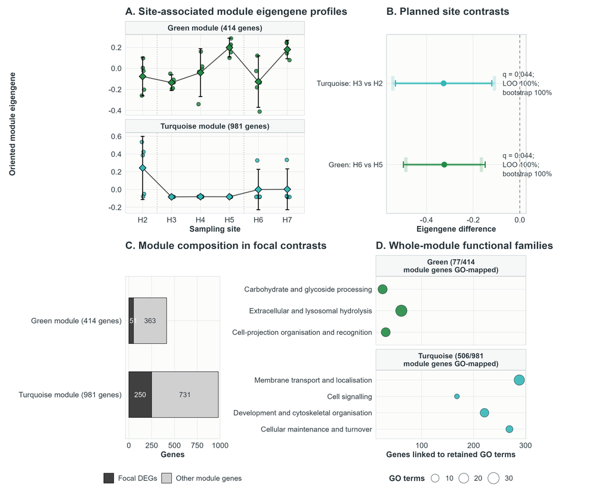

**Figure legend.** Site-associated co-expression modules retained after the predefined site-contrast, module-stability, and contrast-sensitivity gates. (A) Individual-library module eigengene values across the six sampling sites; diamonds and error bars show site means and 95% confidence intervals. Dotted vertical lines mark the H2–H3 and H5–H6 transitions. (B) Planned contrast estimates. Thin intervals are model-based 95% confidence intervals, while thick pale intervals are site-stratified bootstrap 95% intervals. Labels report global BH-adjusted *q*-values and the proportions of leave-one-out and bootstrap estimates retaining the fitted direction. (C) Contrast-specific DEGs and the remaining genes in each complete module. (D) Specific, traceable whole-module functional families assigned from primary-mapping FDR GO terms after excluding generic parent terms. Module eigengene signs are arbitrary. Differential- expression and co-expression analyses summarize the same libraries and provide complementary rather than independent evidence.

## 13.1 Supplementary magenta-module profile

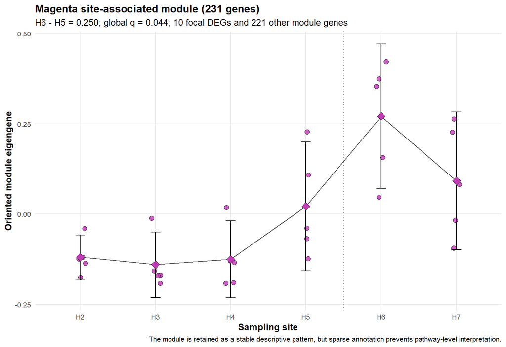

# 14 12. Exploratory interpretation

## 14.1 Analytical outcome

The site-first screen evaluated 18 assigned modules across 30 individual libraries. 5 modules met FDR < 0.05 in the supplementary omnibus overview. 4 of the 54 primary planned module-contrast tests met global FDR < 0.05; 3 distinct modules also passed the formal membership-stability gate, and 2 passed the additional contrast-level robustness rule for main-text display. 15 planned tests combined nominal p < 0.05 with an absolute model-standardized effect >= 1.00. Pairwise Hedges’ g is retained only as an archival diagnostic and does not rank modules.

Whole-module enrichment identified at least one module-level FDR GO term in 4 assigned modules. Ontology-specific Wang reduction produced representative term clusters for 4 modules, while the separate supportive KEGG family identified at least one FDR pathway in 4 modules. These results describe the functional composition of complete modules rather than only the subsets already recovered through differential expression.

The primary EggNOG GO mapping retained annotations for 994 of the 10,000 network genes. The broader Trinotate-union sensitivity mapping retained 1755 genes and is reported only as a robustness comparison. The current GO.db audit flagged 0 obsolete or unresolved identifiers. Paper-facing functional families exclude generic GO parents and remain traceable to their source terms and module genes.

## 14.2 Modules by focal transition

** First WWTP transition H3 vs H2 .** MEturquoise (difference = -0.327, model-standardized effect = -2.00, global q = 0.044; stability = high; paper role = main_text_primary; leading whole-module theme: Other or unresolved function); MEblack (difference = -0.284, model-standardized effect = -1.79, global q = 0.067; stability = low; leading whole-module theme: not resolved).

** Second WWTP transition H6 vs H5 .** MEgreen (difference = -0.324, model-standardized effect = -2.33, global q = 0.044; stability = moderate; paper role = main_text_primary; leading whole-module theme: Other or unresolved function); MEmagenta (difference = 0.250, model-standardized effect = 2.03, global q = 0.044; stability = moderate; paper role = supplementary_stable_sparse_annotation; leading whole-module theme: not resolved).

** Furthest downstream site H7 vs H2 .** MEred (difference = 0.327, model-standardized effect = 2.07, global q = 0.044; stability = low; leading whole-module theme: Other or unresolved function); MEgreen (difference = 0.257, model-standardized effect = 1.85, global q = 0.064; stability = moderate; leading whole-module theme: Other or unresolved function).

## 14.3 Interpretation boundary

Only modules supported in the globally adjusted 54-test planned-contrast family and passing the declared membership-stability gate are eligible for a primary module-level claim. Main-text display additionally requires a contrast direction that survives every focal leave-one-out refit and at least 95% of site-stratified bootstrap samples. Whole-module enrichment, focal DEG overlap, and interpretable high-kME genes strengthen biological interpretation but are complementary summaries of the same transcriptomic dataset, not independent replication. Chemistry and MoA profiles are applied only after biological selection and cannot establish chemical causation.

# 15 13. Automated quality-control gates

Automated final WGCNA quality-control gates.

| check_id | passed | observed | requirement | status |
| --- | --- | --- | --- | --- |
| exactly_30_libraries | TRUE | 30 | 30 individual RNA-seq libraries | PASS |
| exactly_6_sites | TRUE | 6 | six sites | PASS |
| five_libraries_per_site | TRUE | 5;5;5;5;5;5 | five libraries at every site | PASS |
| unique_sample_identifiers | TRUE | 30 | all sample identifiers unique | PASS |
| unique_gene_identifiers | TRUE | 10000 | all network gene identifiers unique | PASS |
| requested_equals_retained_gene_count | TRUE | 10000/10000 | retained/requested gene count equality | PASS |
| finite_positive_expression_variance | TRUE | 10000 | every network gene has finite positive variance | PASS |
| valid_goseq_length_values | TRUE | 10000 | valid positive length for every network gene | PASS |
| minimum_assigned_module_size | TRUE | 90 | >= 50 genes | PASS |
| exact_grey_excluded_from_tests | TRUE | MEblack;MEblue;MEbrown;MEcyan;MEgreen;MEgreenyellow;MEgrey60;MElightcyan;MElightgreen;MEmagenta;MEmidnightblue;MEpink;MEpurple;MEred;MEsalmon;MEtan;MEturquoise;MEyellow | exact MEgrey absent from assigned-module tests | PASS |
| module_labels_match_eigengenes | TRUE | 19/19 | final colour and eigengene label sets identical | PASS |
| dynamic_primary_test_family | TRUE | 54/54 | valid non-grey modules multiplied by three contrasts | PASS |
| all_three_deg_contrasts_loaded | TRUE | 2093;1948;2035 | all three focal contrasts non-empty | PASS |
| h6_h5_deg_nonzero | TRUE | 1948 | H6-H5 DEG count greater than zero | PASS |
| declared_14_network_stability_scheme | TRUE | 14/14 | 10 resamples plus four parameter variants | PASS |
| stability_cache_fingerprint_match | TRUE | TRUE | cache metadata identical to current inputs and settings | PASS |
| no_hard_coded_module_or_family_counts | TRUE | 0 | no stale hard-coded module or test-family counts | PASS |
| no_stale_5000_gene_selection | TRUE | 0 | no stale 5,000-gene final-selection narrative | PASS |
| no_stale_colour_claim | TRUE | 0 | no retained claim tied to an old module colour | PASS |
| contrast_robustness_complete | TRUE | 3/5000 | three focal modules with complete leave-one-out and bootstrap diagnostics | PASS |
| green_retained_for_main_figure | TRUE | MEturquoise;MEgreen | green retained after primary, stability, and contrast-robustness gates | PASS |
| final_wgcna_figure_written | TRUE | TRUE;TRUE | final PNG and PDF figure files present | PASS |
| chemistry_excluded_from_module_selection | TRUE | FALSE | chemistry overlay is downstream context only | PASS |

# 16 14. Output inventory and session information

Core Step 08 output inventory.

| output_group | path | present |
| --- | --- | --- |
| site_tests | ../Results_08_Site_Associated_Module_Functional_Exploration/tables/module_site_omnibus_tests.csv | TRUE |
| site_tests | ../Results_08_Site_Associated_Module_Functional_Exploration/tables/module_planned_site_contrasts.csv | TRUE |
| site_summary | ../Results_08_Site_Associated_Module_Functional_Exploration/tables/module_site_evidence_summary.csv | TRUE |
| module_stability | ../Results_08_Site_Associated_Module_Functional_Exploration/tables/module_stability_by_variant.csv | TRUE |
| module_stability | ../Results_08_Site_Associated_Module_Functional_Exploration/tables/module_stability_summary.csv | TRUE |
| module_stability | ../Results_08_Site_Associated_Module_Functional_Exploration/tables/module_stability_classification_rules.csv | TRUE |
| mapping_audit | ../Results_08_Site_Associated_Module_Functional_Exploration/tables/network_gene_label_resolution.csv | TRUE |
| mapping_audit | ../Results_08_Site_Associated_Module_Functional_Exploration/tables/network_gene_label_resolution_audit.csv | TRUE |
| mapping_audit | ../Results_08_Site_Associated_Module_Functional_Exploration/tables/go_identifier_current_status_audit.csv | TRUE |
| mapping_audit | ../Results_08_Site_Associated_Module_Functional_Exploration/tables/go_mapping_cleaning_summary.csv | TRUE |
| DEG_overlap | ../Results_08_Site_Associated_Module_Functional_Exploration/tables/module_focal_deg_overlap.csv | TRUE |
| whole_module_GO | ../Results_08_Site_Associated_Module_Functional_Exploration/tables/whole_module_goseq_run_summary.csv | TRUE |
| whole_module_GO | ../Results_08_Site_Associated_Module_Functional_Exploration/tables/whole_module_goseq_all_terms.csv | TRUE |
| whole_module_GO | ../Results_08_Site_Associated_Module_Functional_Exploration/tables/whole_module_goseq_significant_terms.csv | TRUE |
| whole_module_GO | ../Results_08_Site_Associated_Module_Functional_Exploration/tables/whole_module_goseq_significant_terms_all_mappings.csv | TRUE |
| whole_module_GO | ../Results_08_Site_Associated_Module_Functional_Exploration/tables/whole_module_go_mapping_sensitivity_comparison.csv | TRUE |
| GO_semantic_reduction | ../Results_08_Site_Associated_Module_Functional_Exploration/tables/whole_module_rrvgo_term_assignments.csv | TRUE |
| GO_semantic_reduction | ../Results_08_Site_Associated_Module_Functional_Exploration/tables/whole_module_rrvgo_representative_terms.csv | TRUE |
| GO_semantic_reduction | ../Results_08_Site_Associated_Module_Functional_Exploration/tables/whole_module_rrvgo_summary.csv | TRUE |
| GO_semantic_reduction | ../Results_08_Site_Associated_Module_Functional_Exploration/tables/whole_module_rrvgo_term_gene_traceback.csv | TRUE |
| GO_semantic_reduction | ../Results_08_Site_Associated_Module_Functional_Exploration/tables/whole_module_rrvgo_cluster_gene_traceback.csv | TRUE |
| supportive_KEGG | ../Results_08_Site_Associated_Module_Functional_Exploration/tables/whole_module_kegg_run_summary.csv | TRUE |
| supportive_KEGG | ../Results_08_Site_Associated_Module_Functional_Exploration/tables/whole_module_kegg_all_pathways.csv | TRUE |
| supportive_KEGG | ../Results_08_Site_Associated_Module_Functional_Exploration/tables/whole_module_kegg_significant_pathways.csv | TRUE |
| supportive_KEGG | ../Results_08_Site_Associated_Module_Functional_Exploration/tables/priority_module_kegg_gene_traceback.csv | TRUE |
| whole_module_function | ../Results_08_Site_Associated_Module_Functional_Exploration/tables/whole_module_functional_summary.csv | TRUE |
| gene_dossiers | ../Results_08_Site_Associated_Module_Functional_Exploration/tables/priority_module_complete_gene_dossiers.csv | TRUE |
| gene_dossiers | ../Results_08_Site_Associated_Module_Functional_Exploration/tables/priority_module_top_hub_gene_dossiers.csv | TRUE |
| chemistry_context | ../Results_08_Site_Associated_Module_Functional_Exploration/tables/priority_module_chemistry_overlay.csv | TRUE |
| integrated_dossiers | ../Results_08_Site_Associated_Module_Functional_Exploration/tables/integrated_site_first_module_dossiers.csv | TRUE |
| added_value | ../Results_08_Site_Associated_Module_Functional_Exploration/tables/paper_facing_module_added_value.csv | TRUE |
| contrast_robustness | ../Results_08_Site_Associated_Module_Functional_Exploration/tables/module_contrast_robustness.csv | TRUE |
| contrast_robustness | ../Results_08_Site_Associated_Module_Functional_Exploration/tables/module_contrast_leave_one_out_estimates.csv | TRUE |
| contrast_robustness | ../Results_08_Site_Associated_Module_Functional_Exploration/tables/module_contrast_bootstrap_estimates.csv | TRUE |
| paper_decision | ../Results_08_Site_Associated_Module_Functional_Exploration/tables/paper_facing_module_decision.csv | TRUE |
| final_figure_source | ../Results_08_Site_Associated_Module_Functional_Exploration/tables/figure_wgcna_final_panel_A_eigengenes.csv | TRUE |
| final_figure_source | ../Results_08_Site_Associated_Module_Functional_Exploration/tables/figure_wgcna_final_panel_B_contrasts.csv | TRUE |
| final_figure_source | ../Results_08_Site_Associated_Module_Functional_Exploration/tables/figure_wgcna_final_panel_C_composition.csv | TRUE |
| final_figure_source | ../Results_08_Site_Associated_Module_Functional_Exploration/tables/figure_wgcna_final_panel_D_functional_families.csv | TRUE |
| final_figure_function | ../Results_08_Site_Associated_Module_Functional_Exploration/tables/paper_facing_module_function_assignment_audit.csv | TRUE |
| final_figure_function | ../Results_08_Site_Associated_Module_Functional_Exploration/tables/paper_facing_module_function_summary.csv | TRUE |
| quality_control | ../Results_08_Site_Associated_Module_Functional_Exploration/tables/final_wgcna_quality_control_gates.csv | TRUE |